# Day 2: The Social Relations Model and Blockmodels

- Show All Code
- Hide All Code
- View Source

Advanced Network Analysis · ICPSR

Author

Shahryar Minhas

Published

July 22, 2026

**NoteHow to use this document**

Open the Day 2 teaching deck.

Everything in here runs. There is no separate script. This *is* the script, with the reasoning left in.

The expensive model fits are wrapped in `cache_fit()`, which stores them in `cache/`. The first person to run a chunk pays for the fit; everyone after loads it in milliseconds. If you change the model code, the cache notices and refits. Delete `cache/` if you want to force honest refits of everything. The blockmodel fits in the second half take well under a second on our networks, so we just run those live; one fit at the very end, a latent-factor model that borrows tomorrow’s machinery for a benchmark, was fit elsewhere and ships precomputed in `data/` (the collapsible in Section 19 records the call and seed that made it). The mixed-membership blockmodel and the SRM on that same data are `cache_fit()`-wrapped like the morning’s models, so you fit those yourself.

You need:

```r
install.packages(c("netify", "blockmodels", "igraph", "NetMix",
                   "ggplot2", "reshape2", "patchwork", "dplyr"))
install.packages(c("posterior", "bayesplot"))  # Only for the self-study asides
remotes::install_github("s7minhas/lame")
```

One warning up front: do **not** reach for the `sbm` package in the second half. It is a fine package, but on more than one of our matrices its solver hits a singular system down in C++ and calls `terminate`, which takes your whole R session with it. That is not an error you can catch. We use `blockmodels` and `NetMix`, which stay inside R.

# 1 Today: one cell of the map, two granularities

Day 1 was about building the object: what counts as a tie, who is in the network, whether it is directed, and whether it is weighted. It also drew the map for the whole course: the dependence in dyadic data is real, and every method here is a different decision about *how to represent it*. Today we take the **latent actor-effects** route twice, at two granularities:

- **First half: the social relations model.** Every actor gets continuous sender and receiver effects, some actors are just more active than others, and that heterogeneity enters the conditional mean additively.
- **Second half: the stochastic blockmodel.** Actors come in a small number of discrete **types**, and those types determine the conditional tie probabilities between actors.

Same broad route, two shapes for latent actor heterogeneity: additive sender/receiver offsets or a discrete type. The seam between the halves, what the offsets *cannot* see and what the types can, is the day’s teaching point, and tomorrow (Day 3) resolves it into a full latent geometry.

Housekeeping: **Homework 3 is due today.** Hand it in before the first break if you have not already. Homework 3 had you fit an SRM self-guided from the packet, so if parts of it felt like following an incantation, good: the first half of today is where everything you did last night clicks into place.

We start with the question that should have been bothering you since yesterday:

> What exactly goes wrong if I just run a regression on dyadic data?

The answer is more interesting than “the standard errors are too small.” Before the first break one of our coefficients will have flipped sign, and it will not be because we did anything to the standard errors.

## 1.1 The Political Science Question Before the Model

Suppose the substantive question is why some states trade more than others. Distance, shared institutions, and prior conflict describe the dyad, but states also carry persistent propensities into every relationship. Some states export broadly. Some are attractive markets. Some pairs have unusually reciprocal exchange. A regression that treats each country-pair as a fresh observation asks the right substantive question with the wrong information structure.

The SRM separates four pieces that political scientists often blur together:

1. **Observed covariate associations:** how trade changes with distance, institutions, conflict, and regime characteristics.
2. **Sender heterogeneity:** which states export more than those covariates predict.
3. **Receiver heterogeneity:** which states import more than those covariates predict.
4. **Reciprocity:** whether unexpectedly high trade from $i$ to $j$ travels with unexpectedly high trade from $j$ to $i$.

The blockmodel asks a different question. Instead of giving every country its own continuous sender and receiver propensity, it asks whether countries occupy a small number of relational types, such as broadly integrated traders, peripheral economies, or groups that exchange heavily with one another but not with outsiders. Those labels are interpretations we earn after fitting; the model initially sees only patterns of ties.

## 1.2 The Applied Model Compass

| Model | Question we want to understand | How the model helps | What makes it distinct | A human interpretation |
| --- | --- | --- | --- | --- |
| Dyadic GLM | How are observed country and dyad characteristics associated with trade? | Gives a familiar conditional-mean benchmark | Treats the rows as conditionally independent and leaves actor heterogeneity and reciprocity unmodeled | “Countries with these observed characteristics trade more in the benchmark, but the model treats every country-pair as fresh information.” |
| SRM | Is the apparent covariate relationship partly a story about persistent exporters, importers, or reciprocal pairs? | Estimates covariate associations together with sender effects, receiver effects, their covariance, and dyadic reciprocity | Represents continuous actor heterogeneity and paired-direction dependence directly | “After accounting for countries’ broader exporting and importing tendencies, the shared-institution association is much smaller than the ordinary regression suggested.” |
| Stochastic blockmodel | Does the network organize into a small number of relational types with different mixing patterns? | Compresses the graph into actor memberships and a block-to-block tie matrix | Represents discrete role structure rather than a separate continuous effect for every actor | “The fitted groups differ mainly in how they trade with other groups, not simply in how dense they are internally.” |
| Mixed-membership blockmodel | Do actors combine several relational roles rather than occupy one box? | Gives each actor a distribution over roles | Allows the same actor to behave as different types across relationships | “This state is mostly an integrated trader but also shows a meaningful peripheral trading profile; the memberships are graded evidence, not natural geopolitical labels.” |

These models do not compete on one universal scoreboard. The SRM is strongest when actor heterogeneity and reciprocity are the question. A blockmodel is strongest when relational types and the mixing among them are the question. The human result should name the pattern the chosen model was built to reveal.

## 1.3 How the Two Estimators Learn

The package calls later in the document are short, but the estimation logic is not mysterious.

### 1.3.1 SRM and AME Estimation by MCMC

For the additive SRM, the algorithm works through the following cycle:

1. **Write the conditional mean.** The linear predictor contains observed covariates, sender effects $a_i$, and receiver effects $b_j$.
2. **Specify distributions for the unobserved pieces.** Sender and receiver effects vary across actors; residuals for $ij$ and $ji$ may be correlated.
3. **Start with provisional values.** The coefficients, actor effects, variance components, and reciprocity parameter all receive initial values.
4. **Update one block conditional on the others.** Given the current actor effects, update $\beta$. Given $\beta$, update sender and receiver effects. Given those effects, update their variances and covariance. Then update dyadic reciprocity.
5. **Repeat the cycle.** After burn-in, retained iterations approximate draws from the joint posterior.
6. **Summarize uncertainty.** Posterior means or medians become point summaries; posterior quantiles become credible intervals.
7. **Simulate networks from the fitted model.** Posterior predictive checks ask whether the fitted model reproduces the network features needed for the substantive claim.

MCMC does not search once and declare a winner. It constructs a distribution over plausible parameter values. That is why trace behavior, effective sample size, and posterior predictive checks are part of estimation rather than optional decoration.

### 1.3.2 Blockmodel Estimation by Variational EM

The stochastic blockmodel uses a different loop:

1. Choose a candidate number of blocks $K$ and initialize each actor’s membership probabilities.
2. Given those provisional memberships, estimate the tie probability for every sender-block and receiver-block pair.
3. Given those block-to-block probabilities, update each actor’s probability of belonging to each block.
4. Alternate the last two steps until the variational objective stops improving meaningfully.
5. Repeat from several initializations because different starts can produce different local solutions.
6. Compare candidate values of $K$, inspect membership uncertainty, and simulate from the fitted model to check the features it reproduces.

Variational estimation replaces an intractable posterior with a tractable approximation. It is fast, but its uncertainty can be optimistic, which is one reason we inspect stability and fit rather than treating the returned partition as observed truth.

We are working with the same cross-sectional directed trade network as yesterday’s closing section: 30 countries, 870 directed dyads.

```r
load("data/day9_srm.rda")   # day9 is the legacy lecture name; this is the day-2 dataset
head(trade[, 1:6])
```

|  | Var1 | Var2 | trade | conflicts | distance | shared_igos |
| --- | --- | --- | --- | --- | --- | --- |
| 2 | AUL | ARG | 0.8891828 | 0 | 11.72 | 3.826683 |
| 3 | BEL | ARG | 0.2700271 | 0 | 11.31 | 3.917409 |
| 4 | BNG | ARG | 0.0000000 | 0 | 16.76 | 3.425239 |
| 5 | BRA | ARG | 0.8700434 | 0 | 2.35 | 4.211387 |
| 6 | CAN | ARG | 0.1906204 | 0 | 9.07 | 3.947776 |
| 7 | CHN | ARG | 1.2528095 | 0 | 19.26 | 3.722314 |

`load()` drops a data frame, `trade`, into your session, one row per directed dyad. `Var1` is the sender $i$, `Var2` the receiver $j$; a `1` suffix on a nodal covariate (`pop1`, `gdp1`, `polity1`) is the sender’s value, a `2` suffix the receiver’s.

The DV is `trade` ($i \rightarrow j$ exports, logged). We have two dyadic covariates that are symmetric (`distance`, `shared_igos`), one that is not (`conflicts`), and three nodal covariates measured for both the sender (`pop1`, `gdp1`, `polity1`) and the receiver (`pop2`, `gdp2`, `polity2`).

# 2 What’s wrong with the GLM?

Let’s write down the model we would have run before this course, and run it.

$$trade_{ij} = \beta_0 + \beta_1 \text{polity}_i + \beta_2 \text{polity}_j
+ \beta_3 \text{conflicts}_{ij} + \beta_4 \text{distance}_{ij}
+ \beta_5 \text{shared igos}_{ij} + \epsilon_{ij}$$

```r
form <- formula(
  trade ~ polity1 + polity2 + conflicts + distance + shared_igos
)
ols <- lm(form, data = trade)
round(summary(ols)$coefficients, 3)
```

```
#>             Estimate Std. Error t value Pr(>|t|)
#> (Intercept)    0.915      0.223   4.099    0.000
#> polity1        0.022      0.006   3.640    0.000
#> polity2        0.028      0.006   4.553    0.000
#> conflicts      0.808      0.118   6.827    0.000
#> distance      -0.033      0.008  -4.315    0.000
#> shared_igos   -0.051      0.056  -0.918    0.359
```

Four of the five covariates are significant, all four at p < 0.001. The exception is `shared_igos` (t = -0.92, p = 0.36). Hold onto that one; by the first break it will have flipped sign. If this is where you stop, you write a paper.

The assumption doing all the work here is that $\{\epsilon_{ij}\}$ are independent. In network data that assumption often fails. What follows depends on *why* they are dependent:

- Biased effect estimates **when omitted network structure is part of the conditional mean and is correlated with an included covariate**
- Badly calibrated intervals when an independence-based variance estimator ignores residual correlation, even if the conditional mean is correct
- Inefficient estimates when the dependence is left unused
- Poor predictive performance
- An inaccurate description of the thing you claim to be describing

Dependence by itself is not a theorem that every coefficient is biased. The point estimate can remain centered under a correctly specified conditional mean and exogenous covariates while its usual standard error is wrong. In our trade example the actor structure also overlaps the regressors, so both the estimates and their uncertainty are at stake. People have made that general argument for decades. What they do not usually do is *check*. So let’s check.

# 3 Beyond stargazing

The trick is simple: if the model were right, the residuals would have no network structure left in them. So pull the residuals out, put them back into a sociomatrix, and look.

```r
trade$olsError <- ols$residuals

# Lazy but readable: preallocate an n x n matrix and fill it
actors <- sort(unique(c(as.character(trade$Var1), as.character(trade$Var2))))
n <- length(actors)
E <- matrix(NA, n, n, dimnames = list(actors, actors))
for (ii in 1:nrow(trade)) {
  E[as.character(trade$Var1[ii]), as.character(trade$Var2[ii])] <- trade$olsError[ii]
}
round(E[1:4, 1:4], 2)
```

```
#>       ARG   AUL   BEL   BNG
#> ARG    NA  0.09 -0.54 -0.45
#> AUL  0.13    NA  0.54 -0.01
#> BEL -0.50  0.52    NA -0.83
#> BNG -0.50 -0.11 -0.76    NA
```

## 3.1 Are the errors reciprocated?

If $i$’s residual toward $j$ tells you nothing about $j$’s residual toward $i$, this correlation should be around zero.

```r
cor(c(E), c(t(E)), use = "complete.obs")
```

```
#> [1] 0.9353999
```

It is not around zero. Dyads that over-trade in one direction over-trade in the other, and the model has no way to know that.

## 3.2 Is there sender and receiver heterogeneity?

Same logic, one dimension up. If a country’s residuals are systematically high across its whole row, the model is systematically wrong about that country.

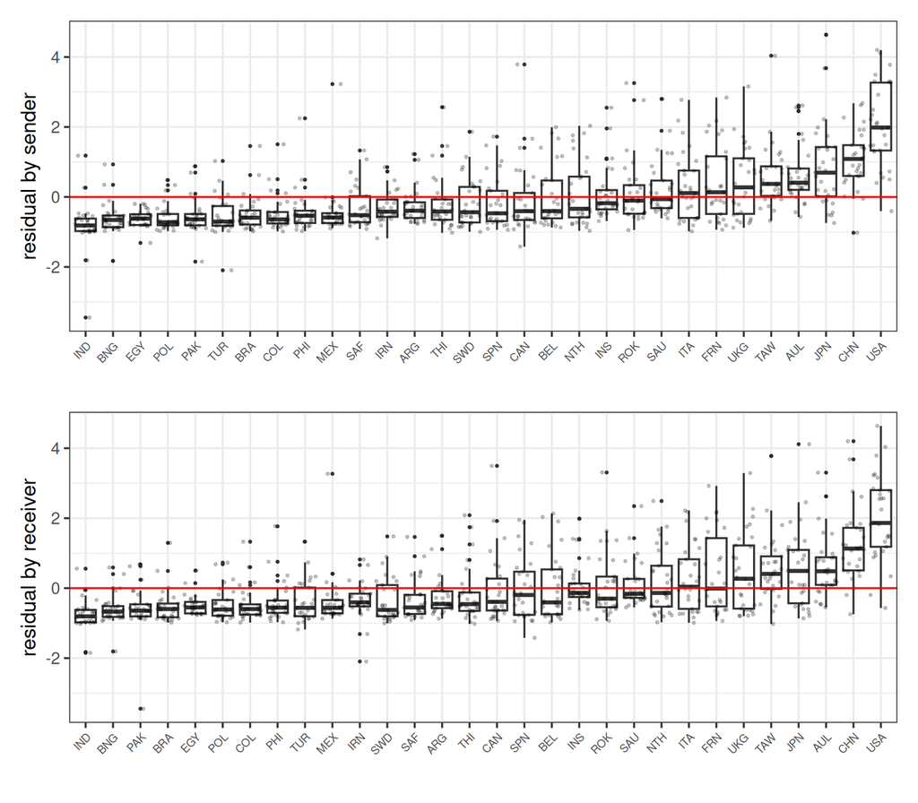

Residuals grouped by sender (top) and by receiver (bottom), with actors sorted by mean residual. Flat bands centered on zero would mean we’re fine.

```r
rowErr <- apply(E, 1, mean, na.rm = TRUE)
colErr <- apply(E, 2, mean, na.rm = TRUE)

errDF <- na.omit(melt(E))
errDF$Var1 <- factor(errDF$Var1, levels = names(sort(rowErr)))
errDF$Var2 <- factor(errDF$Var2, levels = names(sort(colErr)))

gg <- function(x, lab) {
  ggplot(errDF, aes(x = .data[[x]], y = value)) +
    geom_boxplot(outlier.size = .5) +
    geom_jitter(alpha = .2, size = .5) +
    geom_hline(yintercept = 0, color = "red") +
    labs(x = "", y = lab) +
    theme(axis.text.x = element_text(angle = 45, hjust = 1, size = 7))
}
gg("Var1", "residual by sender") / gg("Var2", "residual by receiver")
```

```r
c(sd_sender = sd(rowErr), sd_receiver = sd(colErr))
```

```
#>   sd_sender sd_receiver
#>   0.6164340   0.5977754
```

There is a clear gradient in both panels. Some countries are just more active than `polity`, `distance` and `shared_igos` can explain, and the model is absorbing that into the error term where it does not belong.

## 3.3 Would we see this anyway?

Fair objection: boxplots always look like *something*. So let’s check what this diagnostic looks like when we know the model is correctly specified. Same size network, same procedure, but the data is generated with genuinely independent errors.

```r
set.seed(6886)
sim <- expand.grid(Var1 = letters, Var2 = letters, stringsAsFactors = FALSE)
sim <- sim[sim$Var1 != sim$Var2, ]
sim$x1 <- rnorm(nrow(sim))
sim$x2 <- rnorm(nrow(sim))
sim$y  <- -2 + 3 * sim$x1 + 3.2 * sim$x2 + rnorm(nrow(sim))

simErr <- resid(lm(y ~ x1 + x2, data = sim))
Es <- matrix(NA, 26, 26, dimnames = list(letters, letters))
for (ii in 1:nrow(sim)) Es[sim$Var1[ii], sim$Var2[ii]] <- simErr[ii]

cat("reciprocity in simulated residuals:",
    round(cor(c(Es), c(t(Es)), use = "pairwise.complete.obs"), 3), "\n")
```

```
#> reciprocity in simulated residuals: -0.024
```

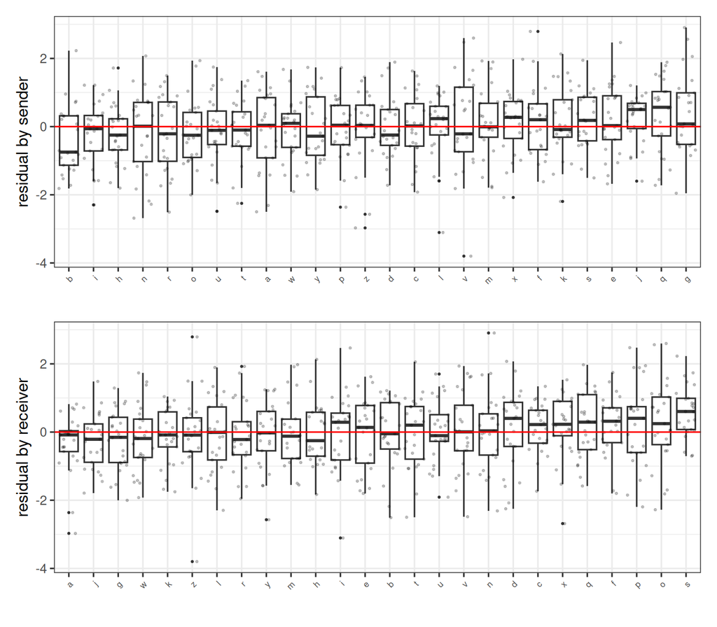

The same diagnostic on data we generated ourselves with IID errors. This is what ‘no structure left’ looks like.

```r
rowErrS <- apply(Es, 1, mean, na.rm = TRUE)
colErrS <- apply(Es, 2, mean, na.rm = TRUE)
errS <- na.omit(melt(Es))
errS$Var1 <- factor(errS$Var1, levels = names(sort(rowErrS)))
errS$Var2 <- factor(errS$Var2, levels = names(sort(colErrS)))

ggS <- function(x, lab) {
  ggplot(errS, aes(x = .data[[x]], y = value)) +
    geom_boxplot(outlier.size = .5) + geom_jitter(alpha = .2, size = .5) +
    geom_hline(yintercept = 0, color = "red") +
    labs(x = "", y = lab) +
    theme(axis.text.x = element_text(angle = 45, hjust = 1, size = 7))
}
ggS("Var1", "residual by sender") / ggS("Var2", "residual by receiver")
```

Reciprocity near zero, and the boxes sit flat on the line. So the pattern in the trade residuals is real, not an artifact of the plot.

**Important**

This is the whole motivation for the rest of this course, and it costs about fifteen lines of code. **Run it on your own data before you model anything.** If your residual sociomatrix is flat, you do not need us.

# 4 The social relations model

David Kenny was studying interpersonal perception, what we think others are like, and how we think others see us, and needed a way to decompose a round-robin of ratings into “who rates highly”, “who gets rated highly”, and “what is specific to this pair”. That decomposition is exactly what we need.

Picture the round-robin literally: a floor of roommates, or a speed-dating night, where everyone rates everyone. Some people are generous raters who mark everybody highly, while some are grumpy; that is a sender effect, $a_i$. Some people are universally liked and get high marks from everyone; that is a receiver effect, $b_j$. The sender-receiver covariance $\sigma_{ab}$ asks whether the generous raters also tend to be the well-liked ones. And reciprocity $\rho$ asks whether you and I specifically click beyond our general tendencies, above and beyond how generous I am and how likeable you are. Trade uses the same decomposition, with exports in place of ratings.

There are four distinct things going wrong above, and the SRM handles each of them with a parameter.

**Sender heterogeneity**

An actor induces dependence across its receivers. Values along a row, $\{y_{ij}, y_{ik}, y_{il}\}$, are more similar to each other than to the rest of the matrix because they share a sender $i$.

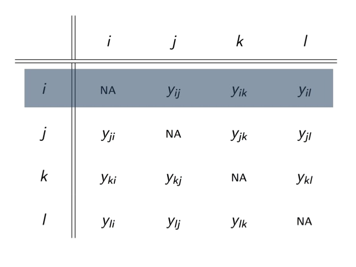

**Receiver heterogeneity**

Same story down a column. $\{y_{ji}, y_{ki}, y_{li}\}$ share a receiver $i$.

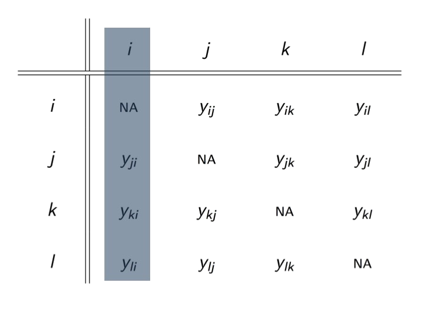

**Sender-receiver covariance**

Actors who send a lot tend also to receive a lot. So the row effect and the column effect are not independent of each other and have to be modeled jointly.

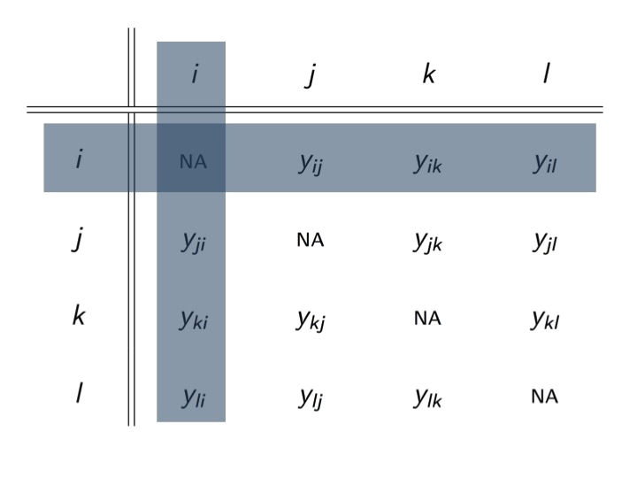

**Reciprocity**

$y_{ij}$ and $y_{ji}$ are dependent, actors respond in kind. This is within-dyad, and it is the thing our residual correlation of 0.94 was picking up.

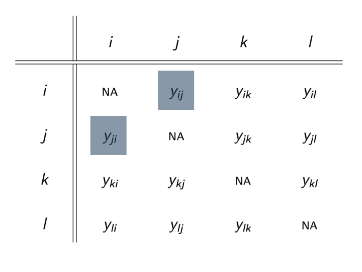

Put together (Warner et al. 1979; Li & Loken 2002):

$$\begin{aligned}
y_{ij} &= \mu + e_{ij} \\
e_{ij} &= a_i + b_j + \epsilon_{ij} \\
\{(a_1,b_1),\ldots,(a_n,b_n)\} &\sim N(0, \Sigma_{ab}) \\
\{(\epsilon_{ij}, \epsilon_{ji}): i \neq j\} &\sim N(0, \Sigma_\epsilon) \\
\Sigma_{ab} = \begin{pmatrix} \sigma_a^2 & \sigma_{ab} \\ \sigma_{ab} & \sigma_b^2 \end{pmatrix}
\qquad
&\Sigma_\epsilon = \sigma_\epsilon^2 \begin{pmatrix} 1 & \rho \\ \rho & 1 \end{pmatrix}
\end{aligned}$$

Reading that off:

- $a_i$ is the sender effect, $b_j$ the receiver effect. These are *random* effects, so we get a variance for each ($\sigma_a^2$, $\sigma_b^2$) as well as the effects themselves.
- $\sigma_{ab}$ is the sender-receiver covariance. Positive means active senders are also popular receivers.
- $\rho$ is reciprocity: the within-dyad correlation in what is left over.
- $\mu$ is a baseline level of activity. For regression we just replace it with $\beta^T X$, which is how we get:

$$y_{ij} = \beta_d^T \mathbf{x}_{d,ij} + \beta_s^T \mathbf{x}_{s,i}
+ \beta_r^T \mathbf{x}_{r,j} + a_i + b_j + \epsilon_{ij}$$

Note what this is and is not. It is a model of first- and second-order dependence. It says nothing about triangles, and we will come back to that right before the break, it is the seam the whole day turns on.

# 5 Building the network object

`netify` does the wrangling; `to_lame()` hands it to the model in the shape `ame()` expects.

```r
net <- netify(
  input   = trade,
  actor1  = "Var1",
  actor2  = "Var2",
  symmetric = FALSE,
  weight  = "trade",
  nodal_vars = c("pop1", "gdp1", "polity1"),
  dyad_vars  = c("conflicts", "distance", "shared_igos"),
  # Conflicts is genuinely directed, 24 directed observations disagree
  # with their reverse (so 12 dyads). Distance and shared_igos are
  # symmetric. Flagging conflicts as symmetric would make netify mirror
  # the upper triangle and silently throw away the lower one
  dyad_vars_symmetric = c(FALSE, TRUE, TRUE)
)
net
```

**WarningThe message netify prints here is a modeling decision, not noise**

`netify` tells you that `missing_to_zero = TRUE` and that missing dyads got filled with zeros. For a *statistical* model that distinction matters: a structural zero (“these two never trade”) and a missing observation (“we don’t know”) are different claims, and `ame()` will happily treat the second as the first.

Our trade matrix is complete, so it does not bite here. On your own data, decide deliberately and pass `missing_to_zero = FALSE` if you mean NA.

```r
lame_data <- to_lame(net)

dv <- lame_data$Y      # n x n matrix
xd <- lame_data$Xdyad  # n x n x pd array
xs <- lame_data$Xrow   # n x ps matrix, sender covariates
xr <- lame_data$Xcol   # n x pr matrix, receiver covariates

sapply(list(Y = dv, Xdyad = xd, Xrow = xs, Xcol = xr), dim)
```

```
#> $Y
#> [1] 30 30
#>
#> $Xdyad
#> [1] 30 30  3
#>
#> $Xrow
#> [1] 30  3
#>
#> $Xcol
#> [1] 30  3
```

The reason we use `to_lame()` rather than hand-rolling `acast()` calls is alignment. `unique()` returns actors in whatever order they appear in your data frame; `acast()` sorts them alphabetically. If you build your DV one way and your nodal covariates the other, your covariates get attached to the wrong actors, and *nothing warns you*. The model runs, the table looks plausible, and it is wrong. `to_lame()` guarantees one actor ordering across all four objects.

# 6 A first fit, and a failure

**NoteBaby MCMC: What the Computer Is Actually Doing**

Think of the model as a set of linked dials. One dial controls the observed covariate coefficients, another the sender effects, another the receiver effects, and others control their variation and reciprocity. Moving one dial changes which settings of the others make sense, so the computer cannot set each one once and walk away.

MCMC takes turns:

1. Start with provisional settings for every unknown quantity.
2. Update the coefficients while temporarily treating the current actor effects and variance components as known.
3. Update the actor effects while temporarily treating the new coefficients and the other quantities as known.
4. Update the variance and reciprocity pieces in the same way.
5. After one complete pass, record the current collection of values and go around again.

That recorded collection is one **draw**. Thousands of draws form a **chain**. They are not thousands of new datasets or thousands of independent countries. They are the computer’s correlated walk through parameter values that remain plausible given the one network and the model.

The first part of the walk can still remember an arbitrary starting point, so we discard it as **burn-in**. A **trace plot** shows the retained draws in the order produced; a healthy trace looks like fuzzy static around a stable level rather than a trend or a stuck staircase. **Thinning** (`odens`) keeps only every $k$th stored draw. It saves space but does not create information. **Effective sample size (ESS)** estimates how many independent draws would carry about as much Monte Carlo information as the correlated draws we kept.

The pile of retained draws lets us report a middle value and an interval rather than pretending there is one perfectly known answer. `fit$BETA` is literally that pile for the regression coefficients, one row per retained draw. For priors, posteriors, and credible versus confidence intervals, use the appendix and the `bayes_aside/` folder after class. This is enough to read today’s trace plots without treating MCMC as a black box.

**Warning**

This first fit is deliberately misconfigured. Watch what happens.

```r
srm_bad <- cache_fit("srm_bad", ame(
  Y = dv, Xdyad = xd, Xrow = xs, Xcol = xr,
  family = "normal", symmetric = FALSE, seed = 6886,
  nscan = 1000, burn = 5000, odens = 1, verbose = FALSE
))
```

`lame` warns that `burn` (5000) is larger than `nscan` (1000). That is fine for the moment, it is telling us we are throwing away most of the work. We come back to it.

First thing you always do after an MCMC fit is check whether the chain actually went anywhere.

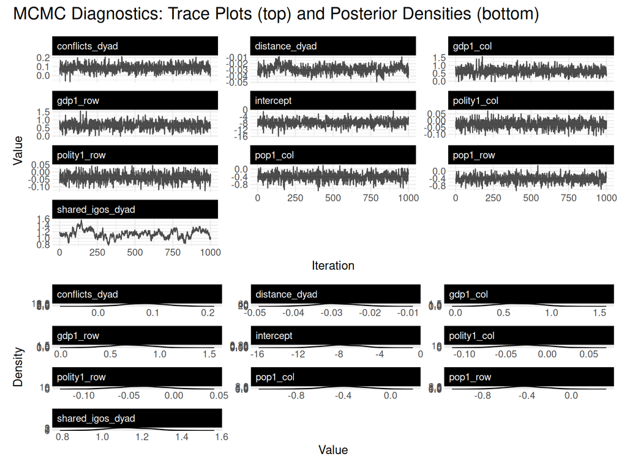

Trace plots from the under-scanned chain. Most of these are fine. Look at shared_igos.

```r
trace_plot(srm_bad, params = "beta")
```

Most of those look like fuzzy caterpillars, which is what you want. `shared_igos` does not, it wanders. Keep an eye on this one, `shared_igos` is about to be the most interesting coefficient in the whole day, and the reason it will not mix here is the same reason it flips later. Let’s put a number on it instead of squinting.

```r
ess(srm_bad)   # Effective sample size per beta, from 1000 saved draws (anti-correlated chains can print a bit over)
```

```
#>        intercept         pop1_row         gdp1_row      polity1_row
#>             1000             1000             1000             1000
#>         pop1_col         gdp1_col      polity1_col   conflicts_dyad
#>             1000             1000             1376              880
#>    distance_dyad shared_igos_dyad
#>               82               27
```

`shared_igos` has an effective sample size in the double digits. We have 1000 draws and only 27 of them are worth anything.

## 6.1 The fix is a longer post-burn-in run, not more burn-in

The reflex is to raise the burn-in. It does not work, and understanding why is one of the most useful things in today’s session.

```r
srm_burn <- cache_fit("srm_burn", ame(
  Y = dv, Xdyad = xd, Xrow = xs, Xcol = xr,
  family = "normal", symmetric = FALSE, seed = 6886,
  nscan = 1000, burn = 10000, odens = 1, verbose = FALSE   # 2x the burn-in
))
ess(srm_burn)
```

```
#>        intercept         pop1_row         gdp1_row      polity1_row
#>              495             1000             1000             1000
#>         pop1_col         gdp1_col      polity1_col   conflicts_dyad
#>             1000             1000             1000             1000
#>    distance_dyad shared_igos_dyad
#>               47               16
```

Twice the burn-in, and `shared_igos` is no better, if anything slightly worse.

**TipWhy burn-in was never the problem**

Burn-in controls *where the chain starts*: how long we let it wander before we begin recording. That is a question about bias at the beginning of the chain.

Our problem is different. The post-burn-in chain is only 1000 iterations long, and consecutive MCMC draws are correlated by construction. The remedy is to run the chain longer so it explores more of the posterior.

The next fit changes two settings at once: it runs 10x as many post-burn-in iterations and stores every 10th draw. The **longer run** is what buys more information. Thinning only keeps the saved object manageable and makes its stored rows less repetitive; it does not create information, and if memory were free we could keep all 10,000 draws. With `odens = 10` we still end up with 1000 stored draws, now spread across a chain that ran 10x as long.

```r
srm <- cache_fit("srm_good", ame(
  Y = dv, Xdyad = xd, Xrow = xs, Xcol = xr,
  family = "normal", symmetric = FALSE, seed = 6886,
  nscan = 10000, burn = 10000, odens = 10, verbose = FALSE  # Scan 10x, keep every 10th
))
ess(srm)
```

```
#>        intercept         pop1_row         gdp1_row      polity1_row
#>              862             1000             1180             1000
#>         pop1_col         gdp1_col      polity1_col   conflicts_dyad
#>             1000             1000             1000             1000
#>    distance_dyad shared_igos_dyad
#>              236              119
```

`shared_igos` goes from 27 to 119, more than four times the effective information among the same 1000 stored draws. Credit the extra chain length, not thinning by itself.

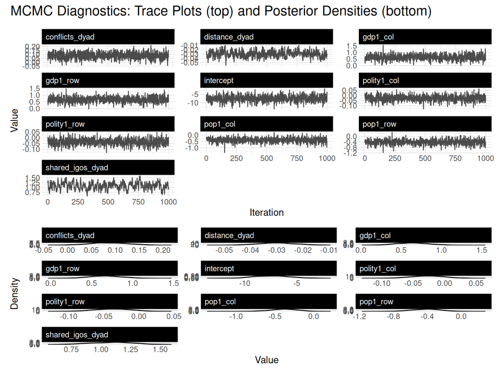

The same model, run for 10 times as many post-burn-in iterations; every 10th draw is stored. Compare shared_igos with the earlier plot.

```r
trace_plot(srm, params = "beta")
```

**NoteA more formal diagnostic, if you want one**

Trace plots and ESS get you most of the way. If you want a test, `coda` has several, and `lame` fits carry their posterior draws in `$BETA` so they drop straight in.

```r
library(coda)
heidel.diag(mcmc(srm$BETA))     # Stationarity
geweke.diag(mcmc(srm$BETA))     # First 10% vs last 50% of the chain
```

```r
dr <- as_draws(srm)
posterior::summarise_draws(dr, ess = posterior::ess_basic)
```

| variable | ess |
| --- | --- |
| intercept | 874.9130 |
| pop1_row | 926.1330 |
| gdp1_row | 972.6589 |
| polity1_row | 951.7636 |
| pop1_col | 889.3972 |
| gdp1_col | 896.1105 |
| polity1_col | 853.9620 |
| conflicts_dyad | 908.2861 |
| distance_dyad | 224.5775 |
| shared_igos_dyad | 135.8269 |
| va | 353.4863 |
| cab | 339.8243 |
| vb | 384.6570 |
| rho | 953.6419 |
| ve | 625.0093 |

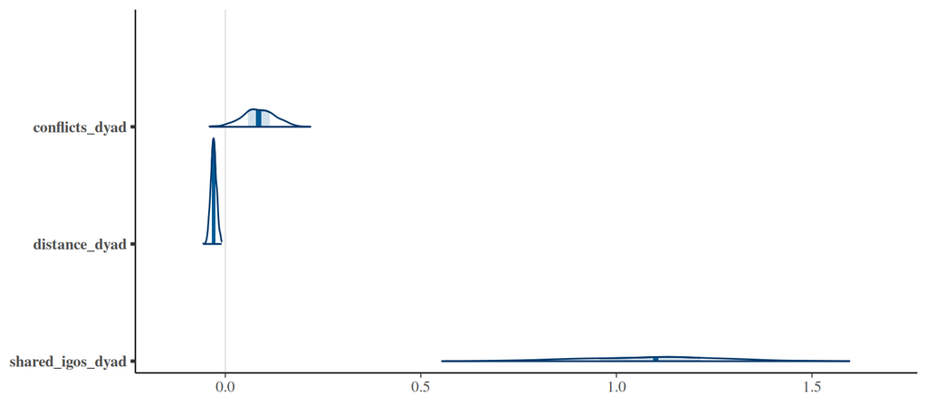

Posterior densities for the dyadic coefficients, straight out of bayesplot. Any function in that package that takes a draws object now works on your fit.

```r
bayesplot::mcmc_areas(dr, regex_pars = "dyad")
```

For the gold standard, several chains from different starting points, compared with R-hat, `ame()` takes `n_chains` and `cores` directly, or `ame_parallel()` with `combine_method = "list"` keeps the chains separate so you can hand them to `compute_mcmc_diagnostics()`:

```r
srm_chains <- cache_fit("srm_chains", ame_parallel(
  Y = dv, Xdyad = xd, Xrow = xs, Xcol = xr,
  family = "normal", symmetric = FALSE, seed = 6886,
  n_chains = 2, cores = 2, combine_method = "list",
  nscan = 10000, burn = 10000, odens = 10, verbose = FALSE
))
mcd <- compute_mcmc_diagnostics(srm_chains)
round(data.frame(rhat = mcd$rhat, ess = mcd$ess), 2)
```

|  | rhat | ess |
| --- | --- | --- |
| intercept | 1 | 2000.00 |
| pop1_row | 1 | 2000.00 |
| gdp1_row | 1 | 2000.00 |
| polity1_row | 1 | 1806.16 |
| pop1_col | 1 | 2000.00 |
| gdp1_col | 1 | 2000.00 |
| polity1_col | 1 | 2000.00 |
| conflicts_dyad | 1 | 1863.92 |
| distance_dyad | 1 | 449.59 |
| shared_igos_dyad | 1 | 215.13 |
| va | 1 | 620.56 |
| cab | 1 | 598.85 |
| vb | 1 | 669.22 |
| rho | 1 | 2000.00 |
| ve | 1 | 1327.18 |

Every R-hat sits at 1, so the two chains agree. Pooling them doubles the information: `shared_igos_dyad` climbs to 215 effective draws against the single chain’s 119.

# 7 What the SRM actually moved

Now the interesting part. To see what the SRM bought us we need something to compare it against, so let’s refit with every network parameter switched off. That gives us an **independence model**, same likelihood, same priors, no sender effect, no receiver effect, no reciprocity.

```r
srm_off <- cache_fit("srm_off", ame(
  Y = dv, Xdyad = xd, Xrow = xs, Xcol = xr,
  family = "normal", symmetric = FALSE, seed = 6886,
  rvar = FALSE, cvar = FALSE, dcor = FALSE, nvar = FALSE, R = 0,
  nscan = 10000, burn = 10000, odens = 10, verbose = FALSE
))
```

Note this is not identical to the `lm` from Section 2, it additionally conditions on population and GDP and is fit in the same Bayesian machinery as the SRM, so its baseline coefficients (`shared_igos` = -0.282, not the `lm()` estimate of -0.051) differ from the raw regression. That is deliberate: it makes the credible intervals line up directly against the SRM. The flip is the independence-model-to-SRM transition.

```r
compare_fits(srm_off, srm, names = c("indep", "srm"))
```

| term | est_indep | est_srm | width_ratio | moved |
| --- | --- | --- | --- | --- |
| intercept | -4.525 | -7.439 | 7.97 |  |
| pop1_row | -0.405 | -0.416 | 6.25 |  |
| gdp1_row | 0.814 | 0.667 | 6.17 |  |
| polity1_row | -0.012 | -0.037 | 5.91 | lost sig |
| pop1_col | -0.370 | -0.387 | 5.96 |  |
| gdp1_col | 0.779 | 0.635 | 6.00 |  |
| polity1_col | -0.003 | -0.027 | 5.88 |  |
| conflicts_dyad | 0.482 | 0.086 | 0.50 |  |
| distance_dyad | -0.047 | -0.030 | 1.43 |  |
| shared_igos_dyad | -0.282 | 1.088 | 4.44 |  |

```r
# The numbers the next three paragraphs quote, pulled from the fits so
# the prose can never silently drift from the table above
b_off <- colMeans(srm_off$BETA); b_srm <- colMeans(srm$BETA)
w_off <- apply(srm_off$BETA, 2, function(x) diff(quantile(x, c(.025, .975))))
w_srm <- apply(srm$BETA, 2, function(x) diff(quantile(x, c(.025, .975))))
nodal <- c("pop1_row", "gdp1_row", "polity1_row",
           "pop1_col", "gdp1_col", "polity1_col")
round(c(median_nodal_width_ratio = median((w_srm / w_off)[nodal])), 2)
```

```
#> median_nodal_width_ratio
#>                     5.98
```

People will tell you the SRM “widens your standard errors.” That is half true, and the half it gets wrong is the half that matters. Read the point estimates and the intervals as two separate stories.

**The nodal covariates pay in width.** `pop1` and `gdp1` barely move as point estimates, `pop1_row` goes from -0.405 to -0.416, about 3%, but their intervals blow up by roughly a factor of 6. That is the SRM being honest. Under the independence model, each country contributed 29 supposedly independent observations to the estimate of a *country-level* covariate. It never did. Your effective sample size for a nodal covariate is closer to the number of actors than the number of dyads, and here that is 30, not 870. `polity1_row` is significant under the independence model and is not under the SRM, purely because of this.

**The dyadic covariates do something else entirely.** `conflicts_dyad` falls from 0.482 to 0.086, an 82% collapse, while its interval gets *narrower*. And `shared_igos_dyad` flips outright, from -0.282 to +1.088. Nothing about widening intervals explains a sign flip. This is the same `shared_igos` that would not converge earlier; both problems have one root: it is nearly collinear with the actor effects.

What happened is that those coefficients were absorbing actor-level variation that had nowhere else to go. We can check this directly. Regress each dyadic covariate on sender and receiver fixed effects and see how much of it is really just about *who is in the dyad*:

```r
r2_fe <- sapply(c("conflicts", "distance", "shared_igos"), function(v) {
  round(summary(lm(trade[[v]] ~ trade$Var1 + trade$Var2))$r.squared, 2)
})
r2_fe
```

```
#>   conflicts    distance shared_igos
#>        0.12        0.39        0.94
```

**Important`shared_igos` is largely actor-compositional in these data**

94% of the variation in `shared_igos` is explained by which two actors are in the dyad. The variable is still defined for a pair, but most of its support here comes from stable actor composition: countries that belong to many IGOs have high values with almost everybody.

Under the GLM, `shared_igos` was also proxying actor-level heterogeneity that had nowhere else to go. Once $a_i$ and $b_j$ enter, the coefficient is based on the remaining variation after that heterogeneity is modeled, and its sign changes. That is evidence of specification sensitivity, not proof that either sign is a causal IGO effect.

This is not a standard-error story, it is omitted-variable bias, and the cure is fixing the MEAN by adding actor effects. That part is shared ground: a fixed-effects specification can absorb additive sender and receiver heterogeneity even when it is correlated with included dyadic covariates, and dyadic cluster-robust standard errors can recalibrate uncertainty. But a time-invariant sender or receiver covariate is collinear with the corresponding actor fixed effects, so fixed effects do not recover a separate coefficient for every nodal predictor. What the SRM adds is a generative dependence model with interpretable variance components, `rho`, and simulated-network GOF. We run a carefully qualified comparison on Day 6.

## 7.1 The same fit, in the package’s own verbs

Everything above leaned on course helpers from `_setup.R`, `ess()`, `coef_tbl()`, `compare_fits()`, because they print exactly the quantity each argument needs and nothing else. But you will not have `_setup.R` next year, and each helper is a thin wrapper over a public verb you should know on sight. The first is `summary()`, the table every paper, replication file and help page will show you:

```r
summary(srm)
```

```
#>
#> === AME Model Summary ===
#>
#> Call:
#> [1] "Y ~ intercept + dyad(conflicts, distance, shared_igos) + row(pop1, gdp1, polity1) + col(pop1, gdp1, polity1) + a[i] + b[j] + rho*e[ji], family = 'normal'"
#>
#> Regression coefficients:
#> ------------------------
#>                  Estimate StdError z_value p_value CI_lower CI_upper
#> intercept          -7.439    1.844  -4.035       0  -11.371   -3.678 ***
#> pop1_row           -0.416    0.183  -2.269   0.023   -0.781   -0.056   *
#> gdp1_row            0.667    0.209   3.195   0.001    0.256    1.074  **
#> polity1_row        -0.037    0.028  -1.321   0.186   -0.092    0.018
#> pop1_col           -0.387    0.187  -2.075   0.038   -0.765   -0.049   *
#> gdp1_col            0.635    0.212   2.998   0.003    0.206    1.041  **
#> polity1_col        -0.027    0.028  -0.971   0.332   -0.083    0.028
#> conflicts_dyad      0.086    0.042   2.059   0.039    0.002    0.164   *
#> distance_dyad       -0.03    0.007  -4.083       0   -0.044   -0.015 ***
#> shared_igos_dyad    1.088    0.182   5.987       0    0.727    1.435 ***
#> ---
#> Signif. codes: 0 '***' 0.001 '**' 0.01 '*' 0.05 '.' 0.1 ' ' 1
#> Note: stars are a visual hint from posterior mean / SD only; for inference use the credible intervals.
#>
#> Variance components:
#> -------------------
#>     Estimate StdError
#> va     0.601    0.195
#> cab    0.517    0.185
#> vb     0.591    0.195
#> rho    0.823    0.017
#> ve     0.183    0.012
#>   (va = sender, cab = sender-receiver covariance, vb = receiver,
#>    rho = dyadic correlation, ve = residual variance)
```

Two reads. The top block is the coefficient table; `coef_tbl()` is its `Estimate`/`CI_lower`/`CI_upper` columns with the stars stripped (and the printout itself tells you to trust the intervals, not the stars). The bottom block is the variance components, the same five numbers we read via `colMeans(srm$VC)` in the next subsection. For programmatic access, `lame` registers the broom verbs: `tidy()` gives the coefficient table as a data frame, and `glance()` gives a one-row fit summary you can stack across models, the portable versions of `coef_tbl()` and `compare_fits()`:

```r
tidy(srm, conf.int = TRUE)
```

| term | estimate | std.error | statistic | p.value | conf.low | conf.high |
| --- | --- | --- | --- | --- | --- | --- |
| intercept | -7.4388160 | 1.8435601 | -4.0350276 | 0.0000546 | -11.3707321 | -3.6783670 |
| pop1_row | -0.4161240 | 0.1833549 | -2.2694997 | 0.0232380 | -0.7812258 | -0.0561150 |
| gdp1_row | 0.6670008 | 0.2087541 | 3.1951512 | 0.0013976 | 0.2563206 | 1.0744767 |
| polity1_row | -0.0371299 | 0.0281012 | -1.3212932 | 0.1864036 | -0.0919739 | 0.0177807 |
| pop1_col | -0.3873475 | 0.1866991 | -2.0747157 | 0.0380129 | -0.7654942 | -0.0493195 |
| gdp1_col | 0.6348855 | 0.2117590 | 2.9981517 | 0.0027162 | 0.2064395 | 1.0413220 |
| polity1_col | -0.0271728 | 0.0279838 | -0.9710188 | 0.3315389 | -0.0832816 | 0.0278643 |
| conflicts_dyad | 0.0857227 | 0.0416254 | 2.0593872 | 0.0394572 | 0.0018661 | 0.1639992 |
| distance_dyad | -0.0298289 | 0.0073058 | -4.0828884 | 0.0000445 | -0.0437762 | -0.0149365 |
| shared_igos_dyad | 1.0884520 | 0.1817903 | 5.9874057 | 0.0000000 | 0.7271430 | 1.4350078 |

```r
dplyr::bind_rows(indep = glance(srm_off), srm = glance(srm),
                 .id = "model")[, c("model", "nobs", "n_actors",
                                    "n_stored", "family", "R")]
```

| model | nobs | n_actors | n_stored | family | R |
| --- | --- | --- | --- | --- | --- |
| indep | 870 | 30 | 1000 | normal | 0 |
| srm | 870 | 30 | 1000 | normal | 0 |

(`ess()` maps to `coda::effectiveSize()` on `fit$BETA`; the collapsible back in Section 6 shows the `posterior`-package route via `as_draws()`. `cache_fit()` is pure caching, nothing statistical hides inside it.)

## 7.2 The random effects are the point, not a nuisance

We usually treat $a_i$ and $b_j$ as things to control away. They are estimates with interpretations, and they are often the most interesting output in the model.

```r
round(colMeans(srm$VC), 3)
```

```
#>    va   cab    vb   rho    ve
#> 0.601 0.517 0.591 0.823 0.183
```

- `va` / `vb`: sender and receiver variance, both around 0.6. Substantial actor heterogeneity, exactly as the residual plots warned.
- `cab`: sender-receiver covariance, strongly positive. Countries that export a lot also import a lot.
- `rho`: reciprocity at 0.82. Trade relationships are extremely mutual, and this is what the GLM was pretending did not exist.
- `ve`: what is left. It is small relative to `va` and `vb`; most of the residual variance in this network was *actor* variance.

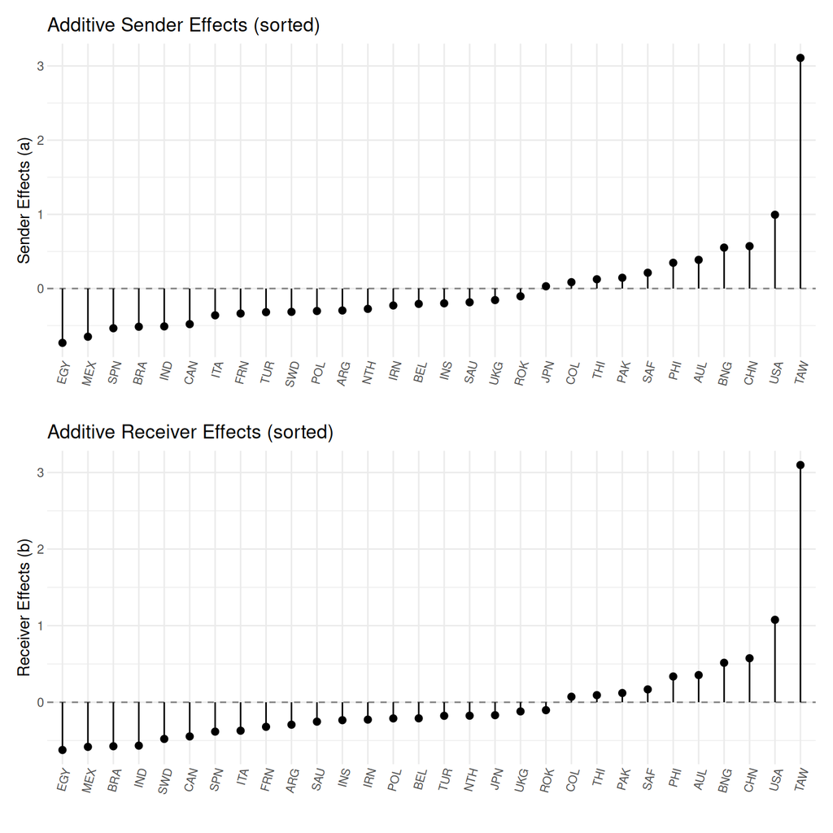

Sender and receiver random effects. These are countries that trade more (or less) than their covariates say they should.

```r
ab_plot(srm, effect = "sender") / ab_plot(srm, effect = "receiver")
```

Two caveats keep this honest. First, $(a,b)$ are assumed jointly normal, a real assumption for a heavy-tailed network like trade and one you can check via the GOF `sd.rowmean` and `sd.colmean` in the next section. Second, the effects plotted here are partially pooled (shrunk) toward that prior rather than being raw actor means. That shrinkage is exactly why they differ from fixed effects and why the nodal intervals widen honestly.

Read these as residual activity after conditioning on population, GDP, polity, distance, conflict, and IGOs. A country high on the sender panel is exporting more than the model can account for. That is a finding, not a nuisance parameter. In Minhas et al. (2022), this is Figure 7, where sender effects from a Reiter & Stam replication turn out to be substantively readable on their own.

**NoteWhat if the DV is binary? Use the same call with `family = "binary"`**

Most dyadic DVs in IR are not continuous. Conflict onset, alliance formation, and whether a trade agreement exists are all binary. The SRM handles this with a Probit link, and the only thing that changes in the call is `family`. We will not walk through it live, read it after class; the fit ships cached.

Let’s dichotomize trade into “is there a substantial trade relationship” and refit.

```r
dv_bin <- 1 * (dv > median(dv, na.rm = TRUE))
diag(dv_bin) <- NA
c(density = round(mean(dv_bin, na.rm = TRUE), 3), ties = sum(dv_bin, na.rm = TRUE))
```

```
#> density    ties
#>   0.498 433.000
```

```r
# NOTE: this one costs about 2 minutes cold, probit adds a latent-variable
# update at every scan. It ships cached; do not refit it in class.
srm_bin <- cache_fit("srm_bin", ame(
  Y = dv_bin, Xdyad = xd, Xrow = xs, Xcol = xr,
  family = "binary", symmetric = FALSE, seed = 6886,
  nscan = 10000, burn = 10000, odens = 10, verbose = FALSE
))
coef_tbl(srm_bin)
```

| term | est | lo | hi | clears_zero |
| --- | --- | --- | --- | --- |
| intercept | -17.957 | -27.395 | -9.380 | yes |
| pop1_row | -1.462 | -2.322 | -0.613 | yes |
| gdp1_row | 2.417 | 1.346 | 3.463 | yes |
| polity1_row | -0.082 | -0.215 | 0.059 |  |
| pop1_col | -1.261 | -2.134 | -0.463 | yes |
| gdp1_col | 2.138 | 1.131 | 3.181 | yes |
| polity1_col | -0.027 | -0.160 | 0.100 |  |
| conflicts_dyad | 0.261 | -0.998 | 1.361 |  |
| distance_dyad | -0.175 | -0.242 | -0.115 | yes |
| shared_igos_dyad | 0.773 | -0.377 | 1.865 |  |

Two things to take away. First, the syntax is identical apart from `family = "binary"`, everything you learned above transfers. Second, the coefficients are now on a Probit scale and are not comparable in magnitude to the normal fit; compare signs and significance, or compute predicted probabilities.

**Why we did not use `conflicts` as the binary DV, even though that is the natural IR choice:** In this dataset `conflicts > 0` happens 26 times across 870 directed dyads, a 3% base rate on a 30-actor network. A Probit SRM on that will give you intervals that cover everything, and the honest reading would be “we cannot tell.” That is worth knowing in itself: **sparse binary networks need more actors, not more iterations.** If your DV fires rarely and your network is small, running the chain longer will not save you.

# 8 Does it fit?

Convergence told you the sampler worked, and the comparison told you what the SRM changed. Neither says the model *describes* the network. For that we simulate networks from the posterior and ask whether they look like the one we observed, on statistics we care about: row and column heterogeneity, dyadic dependence (the reciprocity-flavored statistic), and two flavours of triadic dependence (transitive and cyclic).

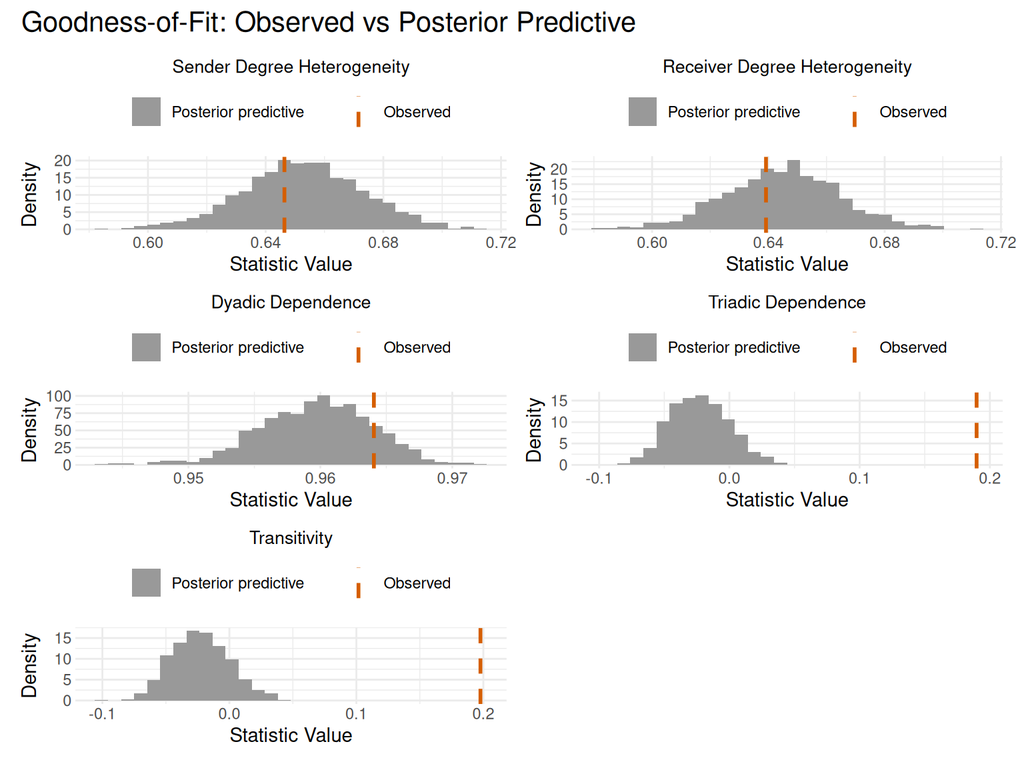

Histograms are networks simulated from the posterior. The vertical line is the observed network. We want the line inside the mass.

```r
gof_plot(srm)
```

One practical line before we score it: for a paper or a slide you rarely want all five panels, and `statistics =` picks the ones under discussion:

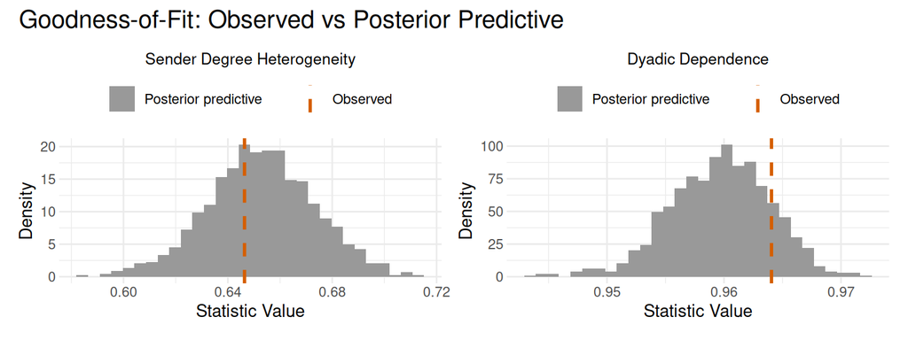

The same GOF object, restricted to the two statistics the SRM is built to hit.

```r
gof_plot(srm, statistics = c("sd.rowmean", "dyad.dep"))
```

Eyeballing “is the line inside the histogram” is fine, but it is easy to argue about, so put a number on it: how many posterior predictive standard deviations away is the observed value?

```r
G <- srm$GOF
obs <- G[1, ]; sim <- G[-1, , drop = FALSE]
gz <- round(sapply(colnames(G), function(s)
  unname(abs(obs[s] - mean(sim[, s])) / sd(sim[, s]))), 2)
gz
```

```
#> sd.rowmean sd.colmean   dyad.dep  cycle.dep  trans.dep
#>       0.30       0.28       1.02       9.34       9.71
```

`sd.rowmean`, `sd.colmean` and `dyad.dep` are all within about one standard deviation, the SRM was built for exactly those, and it delivers. `trans.dep` and `cycle.dep` are off by 9.71 and 9.34. Hold onto that; it is the hinge the whole day turns on.

# 9 The triangle the SRM cannot see

Go back to the GOF numbers. `sd.rowmean`, `sd.colmean` and `dyad.dep` are within a standard deviation. `trans.dep` is off by 9.71; the observed triadic-dependence statistic is 0.198 and our model simulates networks centered near zero (simulated mean -0.02). One wording caution so nobody “catches” the document tonight: `trans.dep` is the normalized residual triple-product the GOF panel plots, **not** the clustering coefficient; running `igraph::transitivity()` on the binarized network gives a different number, on purpose. Either way the verdict stands: it is not a near miss; the model has essentially no idea that triangles exist.

That is not a bug in our fit, and running the chain longer will not touch it. It is structural. The SRM is additive: an actor’s row effect is one number that applies to everyone it sends to. So it can say “Brazil trades a lot,” but it cannot say “Brazil trades a lot *with this particular group of countries*.” Any dependence that requires knowing about a third actor is out of reach.

There are two classic ways that third-order structure shows up:

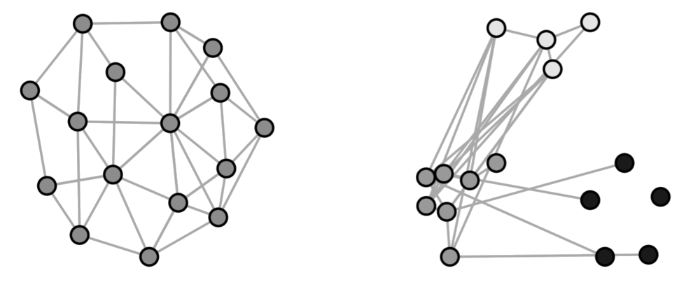

- **Homophily**, birds of a feather flock together. Actors connect to actors who are like them, which mechanically produces triangles.
- **Stochastic equivalence**, no pithy phrase for this one. Actors occupy similar *roles*: they have similar patterns of ties, without necessarily being tied to each other.

These are genuinely different theories of what “similar” means, and they imply different models. The fix comes in two installments, and the first one is right after the break. **The second half of today (blocks)** gives the *discrete* answer, sort actors into roles $z_i$ and let the block-pair effect $\alpha_{z_i z_j}$ enter the conditional mean or link. For binary ties, $\alpha_{ab}=\operatorname{logit}(\theta_{ab})$, where $\theta_{ab}$ is the block-pair tie probability. **Day 3 (distance, then factor/AME)** gives the *continuous* answer, a latent geometry $\gamma(u_i, v_j)$:

$$g\!\left\{\operatorname{E}(Y_{ij}\mid\cdot)\right\}
= \beta^T \mathbf{x}_{ij} + a_i + b_j
+ \underbrace{\alpha_{z_i z_j}}_{\substack{\text{discrete roles}\\\text{today, part two}}}
+ \underbrace{\gamma(u_i, v_j)}_{\substack{\text{latent geometry}\\\text{Day 3}}}$$

**Day 4 (ERGM)** attacks the same triangle gap from the opposite direction. Rather than representing it indirectly through latent actor structure, it writes transitivity directly into the joint graph likelihood. That is a different philosophy, not another $+$ in the conditionally dyad-independent equation above, which is why it is named here but not added to it.

Everything from this morning stays. We are adding to it, not replacing it, and the literal next step, after the break, is the discrete term.

# 10 Your turn, part one

**TipExercises**

Start the core exercise in class and finish the rest tonight.

**Core (everyone).** We showed `shared_igos` is 94% actor-driven. Construct a genuinely dyadic version of it, residualize it on sender and receiver fixed effects, and refit with that in place of the original. Does the sign flip survive?

**Stretch.** The SRM on trade gives us rho = 0.82. Refit with `dcor = FALSE`, which turns reciprocity off but leaves the sender/receiver effects on. What happens to the coefficients, and what happens to the GOF plot? Which statistic breaks?

**Your data (take home).** On your own network: run the residual diagnostic from Section 3. Report the reciprocity correlation and the SD of the row and column residual means. Do you need an SRM?

**Solutions, open after you’ve tried them**

```r
## Core: a genuinely dyadic `shared_igos`
trade$igos_resid <- resid(lm(shared_igos ~ Var1 + Var2, data = trade))
net2 <- netify(
  input = trade, actor1 = "Var1", actor2 = "Var2",
  symmetric = FALSE, weight = "trade",
  nodal_vars = c("pop1", "gdp1", "polity1"),
  dyad_vars = c("conflicts", "distance", "igos_resid"),
  dyad_vars_symmetric = c(FALSE, TRUE, TRUE)
)
ld2 <- to_lame(net2)
srm_resid <- cache_fit("srm_resid", ame(
  Y = ld2$Y, Xdyad = ld2$Xdyad, Xrow = ld2$Xrow, Xcol = ld2$Xcol,
  family = "normal", symmetric = FALSE, seed = 6886,
  nscan = 10000, burn = 10000, odens = 10, verbose = FALSE
))
# And the comparison that answers the question, refit the network-off
# version too, so we can ask whether the glm and the srm still disagree
srm_resid_off <- cache_fit("srm_resid_off", ame(
  Y = ld2$Y, Xdyad = ld2$Xdyad, Xrow = ld2$Xrow, Xcol = ld2$Xcol,
  family = "normal", symmetric = FALSE, seed = 6886,
  rvar = FALSE, cvar = FALSE, dcor = FALSE, nvar = FALSE, R = 0,
  nscan = 10000, burn = 10000, odens = 10, verbose = FALSE
))
compare_fits(srm_resid_off, srm_resid, names = c("glm", "srm"))

# The sign flip is gone, and not partly gone, completely. The glm
# says 1.509, the srm says 1.528, and the intervals are the same width
# (ratio 0.98). The two models now agree about igos to within about 1%.
#
# That is the cleanest possible demonstration of the claim in the
# 'what the srm actually moved' section: the disagreement was never
# about igos, it was about actor heterogeneity, and once you remove the
# actor component by hand, which is exactly the sender+receiver
# fixed-effects cure, you have done by hand what the srm does by
# shrinkage on that one variable.
#
# Two things residualizing did NOT fix, both worth noticing:
#   - conflicts_dyad still collapses (0.551 -> 0.090). You fixed one
#     variable, not the model. The other dyadic covariates were
#     leaning on the independence assumption too.
#   - The nodal covariates still widen ~4x and polity1_row still
#     loses significance. No amount of residualizing dyadic variables
#     changes the fact that your effective n for a country-level
#     covariate is 30, not 870. That is not a specification problem,
#     it is arithmetic.

## Stretch: turning reciprocity off
srm_norecip <- cache_fit("srm_norecip", ame(
  Y = dv, Xdyad = xd, Xrow = xs, Xcol = xr,
  family = "normal", symmetric = FALSE, seed = 6886,
  dcor = FALSE,
  nscan = 10000, burn = 10000, odens = 10, verbose = FALSE
))
compare_fits(srm, srm_norecip, names = c("srm", "no_recip"))
gof_plot(srm_norecip)

# dyad.dep is the statistic that breaks, and it breaks hard: it goes
# from ~1 posterior predictive sd away to ~9.8. We told the model
# reciprocity does not exist, so it can no longer reproduce the
# reciprocity that is plainly there.
#
# The coefficients split the same way they did in the 'what the srm
# actually moved' section, which is the real point of the exercise. The
# nodal covariates barely notice (widths move 1.06-1.14x, point
# estimates ~5%). The dyadic ones do: conflicts_dyad goes 0.086 ->
# 0.271, roughly tripling. Reciprocity is a *dyad-level* error
# structure, so mis-specifying it distorts dyad-level coefficients and
# leaves nodal ones alone. Same nodal / dyadic divide, third time today.

## Your data
# Fit whatever glm you would have fit, then:
#   e <- resid(your_model)
#   E <- <put e back into an n x n matrix, as in the stargazing section>
#   cor(c(E), c(t(E)), use = "complete.obs")
#   sd(rowMeans(E, na.rm = TRUE)); sd(colMeans(E, na.rm = TRUE))
# Compare against the simulated iid benchmark we built above.
```

**NoteExtra practice: reading the random effects (do it tonight)**

Pull the receiver effects out of `srm` and find the countries that are high senders but low receivers. What would explain that pattern in trade data?

**Solution**

```r
# Note: srm$APM and srm$BPM are named vectors, so take actor names
# from there. Do NOT reach for rownames(srm$U), we fit with R = 0,
# so there is no U in this object yet. That shows up on Day 3.
ab <- data.frame(actor = names(srm$APM), send = srm$APM, recv = srm$BPM)
ab$gap <- ab$send - ab$recv
head(ab[order(-ab$gap), ], 5)   # Export-heavy
head(ab[order(ab$gap), ], 5)    # Import-heavy
# You should get JPN, SWD, SAU, BRA, IND at the top and SPN, TUR,
# EGY, NTH, POL at the bottom. The important thing to notice is that
# these are *residual* after GDP and population, so this is not the
# "big country" ranking, it is a ranking of who trades more
# asymmetrically than their size implies. Saudi Arabia showing up as
# export-heavy is the easy story; Japan and Sweden are the ones worth
# arguing about.
```

**NoteThe full toolbox: the rest of the lame surface**

This optional self-study section covers the remainder of what a fitted `ame` object can do, collected in one place so this document is a complete reference. Everything runs against the cached `srm` from this morning.

**The standard extractors.** Beyond `summary()`/`tidy()`/`glance()` from Section 7, the base-R verbs all work:

```r
round(coef(srm), 3)      # Posterior means, nothing else
```

```
#>        intercept         pop1_row         gdp1_row      polity1_row
#>           -7.439           -0.416            0.667           -0.037
#>         pop1_col         gdp1_col      polity1_col   conflicts_dyad
#>           -0.387            0.635           -0.027            0.086
#>    distance_dyad shared_igos_dyad
#>           -0.030            1.088
```

```r
round(confint(srm), 3)   # 95% credible intervals from the draws
```

```
#>                     2.5%  97.5%
#> intercept        -11.371 -3.678
#> pop1_row          -0.781 -0.056
#> gdp1_row           0.256  1.074
#> polity1_row       -0.092  0.018
#> pop1_col          -0.765 -0.049
#> gdp1_col           0.206  1.041
#> polity1_col       -0.083  0.028
#> conflicts_dyad     0.002  0.164
#> distance_dyad     -0.044 -0.015
#> shared_igos_dyad   0.727  1.435
```

**Fitted values.** `fitted()` returns the posterior-mean expected value for every dyad, the fastest possible “is this model in the right universe” check:

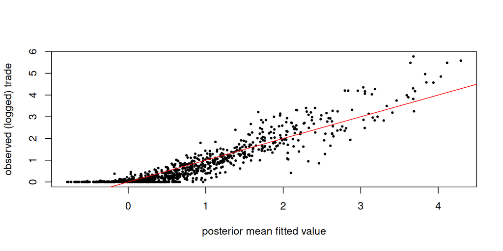

Posterior-mean fitted values against the observed DV, one point per directed dyad. The red line is y = x.

```r
plot(c(fitted(srm)), c(dv), pch = 19, cex = .4,
     xlab = "posterior mean fitted value", ylab = "observed (logged) trade")
abline(0, 1, col = "red")
```

The correlation is 0.92, but do not confuse in-sample agreement with fit; the GOF simulations in Section 8 are the honest scorecard.

**Simulating whole networks.** `gof_plot()` consumed simulated networks without ever showing them to you. `simulate_posterior()` hands you the raw draws so you can do anything you want with them:

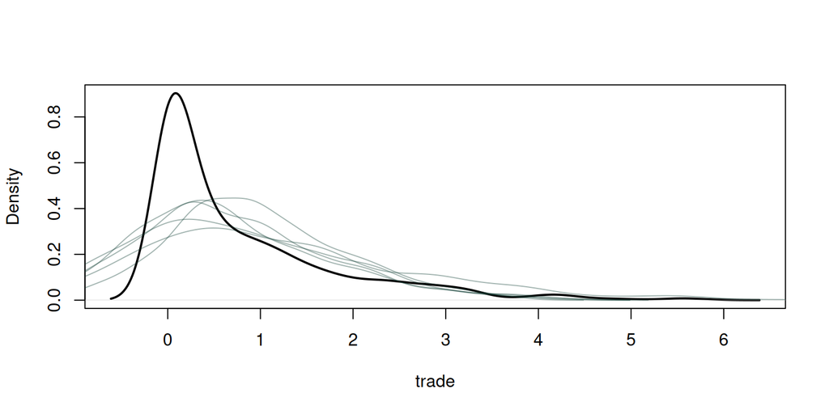

```r
Ysim <- simulate_posterior(srm, component = "Y", n_samples = 5, seed = 6886)
plot(density(dv, na.rm = TRUE), lwd = 2, main = "", xlab = "trade")
for (s in 1:5) lines(density(Ysim[, , s], na.rm = TRUE), col = "#18453B66")
```

**GOF on a statistic you invent.** The five built-in GOF statistics are not a closed list (`gof_stats(Y)` is the function that computes them on any matrix), `gof()` (and `ame(custom_gof = )` at fit time) takes any function of a network matrix:

```r
# The function must take a matrix Y and return a (named) number
gof_clust <- function(Y) {
  A <- 1 * (Y > median(Y, na.rm = TRUE)); diag(A) <- 0
  igraph::transitivity(igraph::graph_from_adjacency_matrix(A, mode = "directed"))
}
set.seed(6886)
G_c <- gof(srm, custom_gof = list(clustering = gof_clust), nsim = 100,
           verbose = FALSE)
round(abs(G_c[1, "clustering"] - mean(G_c[-1, "clustering"])) /
        sd(G_c[-1, "clustering"]), 2)
```

```
#> [1] 2.63
```

The observed clustering coefficient sits 2.6 posterior-predictive SDs above the simulations, gentler than the residual-based `trans.dep` read in Section 9, but the same direction: the SRM under-produces triangles however you choose to count them.

**The priors are yours to override.** Every fit today used the defaults. `prior = list(...)` changes them, and it is worth doing once just to see what the defaults were protecting you from. Here we tighten the prior on the sender/receiver covariance matrix (`Sab0` scales it, `eta0` is its prior degrees of freedom) and watch the actor variances get crushed:

```r
srm_tight <- cache_fit("srm_tight", ame(
  Y = dv, Xdyad = xd, Xrow = xs, Xcol = xr,
  family = "normal", symmetric = FALSE, seed = 6886,
  prior = list(Sab0 = diag(2) * 0.1, eta0 = 60),
  nscan = 10000, burn = 10000, odens = 10, verbose = FALSE
))
round(rbind(default_prior = colMeans(srm$VC),
            tight_prior   = colMeans(srm_tight$VC)), 3)
```

```
#>                  va   cab    vb   rho    ve
#> default_prior 0.601 0.517 0.591 0.823 0.183
#> tight_prior   0.150 0.076 0.149 0.836 0.198
```

`va` and `vb` drop by a factor of 4 with the same data but a different prior. If a reviewer asks “How sensitive are your variance components to the prior,” this two-fit comparison is the answer, and `prior_summary()` prints exactly what was in effect:

```r
prior_summary(srm)
```

Multi-chain fitting and the `posterior`/`bayesplot` bridge live in the collapsible at the end of Section 6; the families and estimators we did not touch at all are listed in Section 22.

Break. First half done: dependence represented through additive actor effects. The GLM and SRM disagree about shared_igos, and the SRM gives nodal predictors much wider intervals. After the break: the same latent-effects route at the group level, actors as discrete types.

# 11 The bridge: you already know how to find communities

Before the break, the SRM gave every actor its own continuous number and could not see a triangle. The blockmodel’s bet is that the actors come in a small number of **discrete types**, and that the only thing you need to know to predict a tie between $i$ and $j$ is which type each one is. That is a strong, falsifiable claim, and it is genuinely different from the additive story behind it and the continuous-geometry story tomorrow. By the end of today you will be able to fit it, choose how many types, check whether the claim holds, and read the answer off a real network.

The promise for this half: we will take a network, *forget* how it was built, find its groups, and then recover the exact recipe that generated it, including a kind of structure that community detection literally cannot see.

Two small plotting helpers get used all afternoon. One draws an adjacency matrix as a heat-tiled image (optionally reordered so block-mates sit together), the other draws a $K \times K$ block-connectivity matrix as a labelled heatmap. They are plain `ggplot2`; run this once and forget it.

**Plotting helpers, run once**

```r
# Draw an adjacency matrix as a heat-tiled image, optionally reordered
# so that actors in the same block sit next to each other. Blocks show
# up as dense squares on the diagonal (or off it).
plot_adj <- function(A, blocks = NULL, title = "",
                     low = "white", high = "grey15") {
  if (!is.null(blocks)) {
    ord <- order(blocks)
    A <- A[ord, ord]
  }
  df <- melt(A)
  df$Var1 <- factor(df$Var1, levels = rev(rownames(A)))
  df$Var2 <- factor(df$Var2, levels = colnames(A))
  ggplot(df, aes(Var2, Var1, fill = value)) +
    geom_tile() +
    scale_fill_gradient(low = low, high = high) +
    coord_equal() + labs(x = "", y = "", title = title, fill = "") +
    theme_minimal(base_size = 11) +
    theme(axis.text = element_blank(), axis.ticks = element_blank(),
          panel.grid = element_blank(), legend.position = "right")
}

# Draw a K x K block-connectivity matrix (theta) as a labelled heatmap
plot_theta <- function(theta, title = "") {
  df <- melt(theta); df$Var1 <- factor(df$Var1); df$Var2 <- factor(df$Var2)
  ggplot(df, aes(factor(Var2), factor(Var1), fill = value)) +
    geom_tile(color = "white") +
    geom_text(aes(label = round(value, 2)), size = 4.2) +
    scale_fill_gradient(low = "#FFFFFF", high = "#18453B") +
    coord_equal() +
    labs(x = "block of j", y = "block of i", title = title, fill = "") +
    theme_minimal(base_size = 12) +
    theme(panel.grid = element_blank())
}
```

Olga spent a good chunk of her week on community detection, so let’s not relitigate it. (If you did not take that workshop: community detection = algorithms that sort actors into densely-tied groups, and you are about to run one, that is all you need for today.) Let’s do it once, on a network with obvious group structure, and then ask what a *model* would add.

Here is a 60-actor network. Never mind for a moment where it came from.

```r
set.seed(6886)
n <- 60
z_true <- rep(1:3, each = 20)          # Three groups of 20, the truth
theta_true <- matrix(0.05, 3, 3)       # 5% chance of a cross-group tie
diag(theta_true) <- 0.45               # 45% chance within a group
# theta_true[z_true, z_true]: for every pair (i, j) look up i's block
# (row) and j's block (column) and return that cell -> a 60x60 grid of
# per-pair tie probabilities. Peek at just actors 1 and 30 (blocks 1, 2):
theta_true[z_true[c(1, 30)], z_true[c(1, 30)]]  # Within .45, between .05
```

```
#>      [,1] [,2]
#> [1,] 0.45 0.05
#> [2,] 0.05 0.45
```

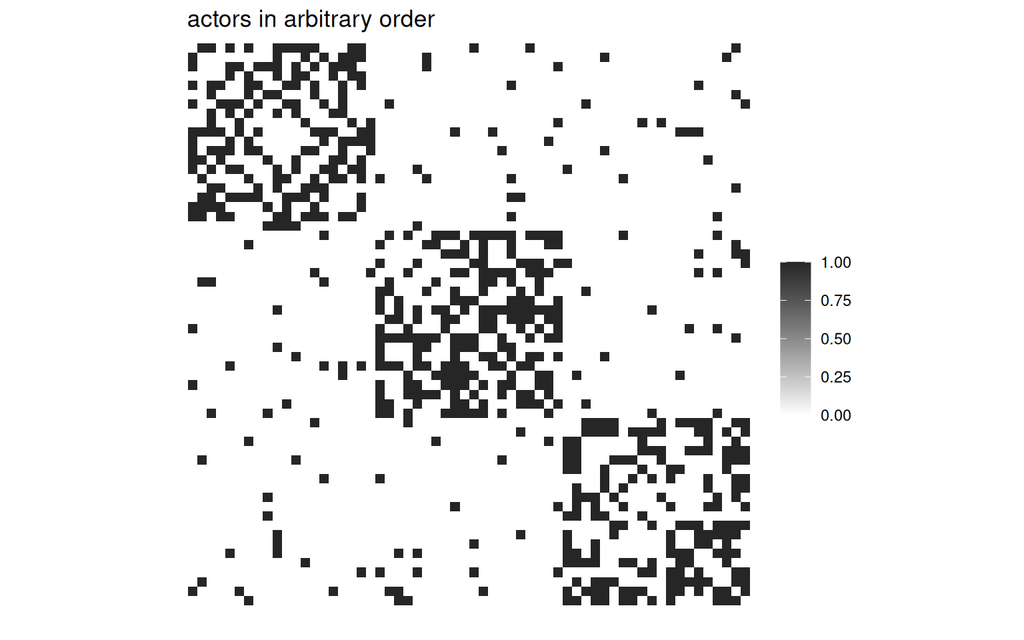

```r
P <- theta_true[z_true, z_true]        # The full 60x60 per-pair grid
A <- matrix(rbinom(n * n, 1, P), n, n) # Flip a coin for every pair
A[lower.tri(A)] <- t(A)[lower.tri(A)]  # Make it symmetric
diag(A) <- 0
dimnames(A) <- list(1:n, 1:n)

plot_adj(A, title = "actors in arbitrary order")
```

The network has 328 edges among 60 actors, a density of 0.185. Now let’s find its communities the way you already know how, with the Louvain algorithm from `igraph`.

```r
g  <- graph_from_adjacency_matrix(A, mode = "undirected", diag = FALSE)
set.seed(6886)
lc <- cluster_louvain(g)
c(n_communities = length(unique(membership(lc))),
  modularity    = round(modularity(lc), 3))
```

```
#> n_communities    modularity
#>         3.000         0.486
```

Louvain finds 3 communities and reports a modularity of 0.49, which is high. Calibrate that number honestly: in practice values above ~0.3 already indicate substantial community structure, and the maximum attainable for $K$ equal-sized groups is about $1 - 1/K$ (about 0.67 here, before the between-group edges eat into it), so 0.49 on a three-group network is close to the ceiling. Do not wait for values “near 1,” which realistic networks cannot reach. Reorder the adjacency matrix by the communities Louvain found and the structure jumps out:

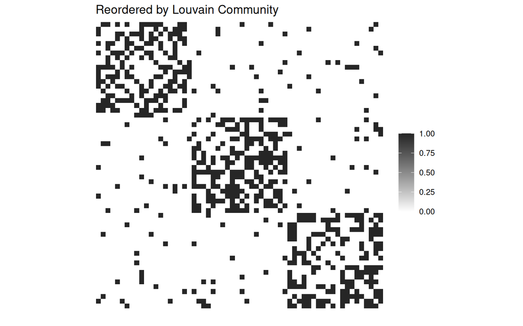

The same matrix, with actors reordered so community-mates are adjacent. Three dense blocks sit on the diagonal: within-community ties are common, and between-community ties are rare.

```r
plot_adj(A, blocks = membership(lc), title = "Reordered by Louvain Community")
```

That is a good answer. It is also a **limited** one, and the limits are the reason this course keeps going.

**ImportantWhat modularity maximization gives you, and what it does not**

The community detection you just ran, **modularity maximization**, the family Louvain and Leiden belong to, hands you a **partition** (a label for every actor) and a **score** (modularity) for how good it is. That is often exactly what you want.

What it does not give you:

- **A likelihood.** Modularity is a score, not a probability. You cannot ask “how probable is this network under this grouping,” which means you cannot compare groupings the way you compare statistical models, and you cannot put the grouping inside a larger model.
- **Uncertainty.** Every actor gets a hard label. There is no “actor 34 is 70% group A, 30% group B”, no probabilistic assignment at all.
- **A generative story.** You cannot run modularity *forward* to simulate a new network, so you cannot do a posterior predictive check, and you cannot predict a held-out tie.
- **Anything but assortative structure.** Modularity is *defined* to reward within-group density. It can only find groups whose members cling together. We will build a network in a few minutes whose real structure this instinct is blind to.

One scope note, and it is the whole reason today’s second reading exists: these are limits of *modularity maximization*, not of community detection writ large. The modern community-detection literature is largely built on the stochastic blockmodel itself, degree-corrected SBMs, Peixoto’s MDL formulation, mixed-membership variants, so today’s model is not the *alternative to* community detection, it is its likelihood-based core. Indeed Newman (2016) showed that modularity maximization is secretly maximum likelihood for a special degree-corrected SBM with its parameters frozen, which is precisely why it cannot adapt to a non-assortative $\theta$. That is exactly why Abbe (2018), “community detection and stochastic block models,” is the bridge paper for the day.

The honest way to say “there are three groups” is to write down a model that could have *generated* this network. That model is the **stochastic blockmodel**, and here is the punchline: I already used it to make the network above. The `theta_true` matrix and the `z_true` labels in the `make-net` chunk *are* an SBM. Let’s unpack the recipe.

# 12 The generative story

A stochastic blockmodel is a recipe for building a network. It has two ingredients:

1. A **block membership** for every actor, $z_i \in \{1, \dots, K\}$. Each of the $n$ actors is assigned to one of $K$ blocks.
2. A **block-connectivity matrix** $\theta$, of size $K \times K$. The entry $\theta_{ab}$ is the probability that an actor in block $a$ ties to an actor in block $b$.

To generate a network you do exactly what the `make-net` chunk did: for every pair $(i, j)$, look up the two actors’ blocks, read off $\theta_{z_i z_j}$, and flip a coin with that probability. Formally:

$$\Pr(Y_{ij} = 1 \mid z_i, z_j) = \theta_{z_i z_j}.$$

The plain SBM also makes a load-bearing conditional-independence assumption: **given all memberships $z$ and the block matrix $\theta$, distinct dyads are independent coin flips.** Before conditioning, dyads that share actors are dependent because they share the same unobserved memberships. After conditioning, any leftover reciprocity, closure, or actor-specific activity has nowhere to go unless the model is extended. That is why simulation-based GOF later in the day is a real model check, not decoration.

That is the whole model. Every actor in the same block is **stochastically equivalent**, interchangeable as far as the network is concerned. The model does not care *who* actor $i$ is, only *which block* it is in. (This is the same “stochastic equivalence” from the seam before the break, the blockmodel is its discrete embodiment.)

**TipWhy this is a good deal: compression**

Count the parameters. A fully saturated model, a separate tie probability for every pair, needs $n(n-1)/2$ numbers; for our 60-actor network that is 1770. The blockmodel needs $n$ block assignments (one per actor) plus a $K \times K$ table of probabilities (of which the symmetric table really has only $K(K+1)/2 = 6$ unique entries). For $K = 3$ that is 66 numbers instead of 1770. The blockmodel is a **compression** of the network: it claims the 1770 pairwise probabilities are really just 6 unique block-level probabilities in disguise. Model selection (Section 15) is the question of how hard we are allowed to compress.

Here is the recipe run forward, with the block structure now made explicit. This is the same generation as before, written to show the two ingredients:

```r
theta_true
```

```
#>      [,1] [,2] [,3]
#> [1,] 0.45 0.05 0.05
#> [2,] 0.05 0.45 0.05
#> [3,] 0.05 0.05 0.45
```

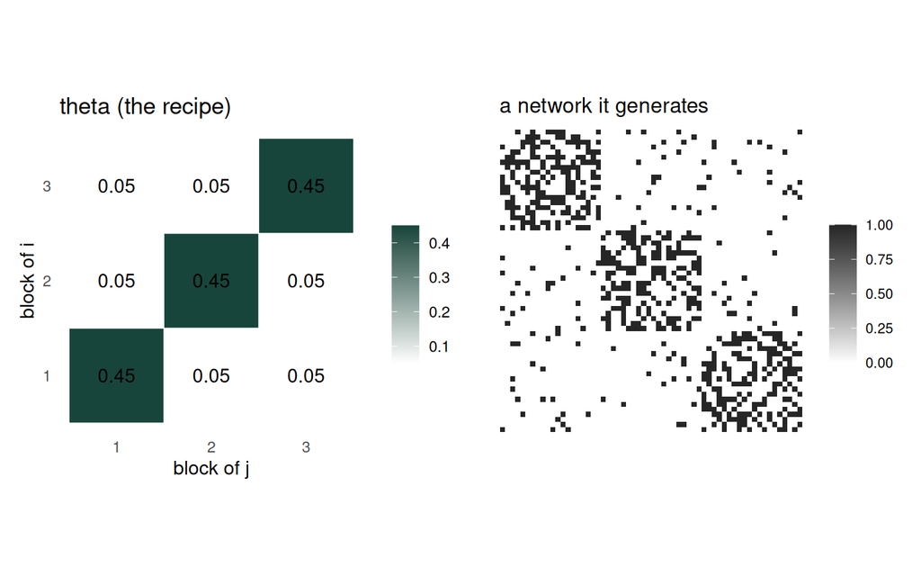

Left: the 3-by-3 block-connectivity matrix theta, dark on the diagonal and light off it. Right: one network simulated from it, with actors ordered by their true block. The theta on the left is the DNA of the blocks on the right.

```r
sim_sbm_binary <- function(z, theta) {
  n <- length(z)
  P <- theta[z, z]
  A <- matrix(rbinom(n * n, 1, P), n, n)
  A[lower.tri(A)] <- t(A)[lower.tri(A)]
  diag(A) <- 0
  dimnames(A) <- list(seq_len(n), seq_len(n))
  A
}
set.seed(7)
A2 <- sim_sbm_binary(z_true, theta_true)

plot_theta(theta_true, "theta (the recipe)") +
  plot_adj(A2, blocks = z_true, "a network it generates")
```

The point of showing the generation first is that **estimation is just this recipe run backwards.** We observe the network on the right; we do not observe the blocks or the theta on the left; and we want to recover them. Everything for the rest of the day is inverting this picture.

**NoteThe model is more general than “communities”**

Nothing in the recipe says $\theta$ has to be dark on the diagonal. That is a special case, the *assortative* case, where blocks are communities. But $\theta$ is an arbitrary $K \times K$ matrix, so it can encode structures community detection has no vocabulary for:

- **Core-periphery:** one block ties to everyone (itself included), the other ties to almost no one. $\theta = \left(\begin{smallmatrix} .8 & .3 \\ .3 & .03 \end{smallmatrix}\right)$.
- **Hierarchy / disassortative:** blocks tie to *other* blocks but not themselves, like a bipartite-ish “this group talks to that group.” $\theta$ has a light diagonal and dark off-diagonal.

Section 16 builds the core-periphery case explicitly and watches community detection fail on it. Hold that thought; first we learn to estimate.

# 13 The likelihood

We said community detection has no likelihood and the blockmodel does. Here it is. ($Y$ is the adjacency matrix, the object we call `A` in code.) Given a full set of block assignments $z$ and a connectivity matrix $\theta$, the probability of the *entire observed network* is the product over all pairs of the coin-flip probabilities:

$$L(z, \theta \mid Y) \;=\;
\prod_{i < j} \; \theta_{z_i z_j}^{\,Y_{ij}}
\,\bigl(1 - \theta_{z_i z_j}\bigr)^{\,1 - Y_{ij}} .$$

Read the two pieces off the exponents. When the pair is tied ($Y_{ij} = 1$) the term is $\theta_{z_i z_j}$, the model’s probability of exactly that tie. When the pair is not tied ($Y_{ij} = 0$) the term is $1 - \theta_{z_i z_j}$, the probability of exactly that non-tie. Multiply across every pair and you have the probability of the whole adjacency matrix. In logs, which is what anyone actually computes,

$$\log L(z, \theta \mid Y) \;=\;
\sum_{i < j} \Bigl[\, Y_{ij}\log\theta_{z_i z_j}
+ (1 - Y_{ij})\log\bigl(1 - \theta_{z_i z_j}\bigr) \Bigr].$$

The $i<j$ index matters because this example is undirected: each unordered pair contributes once. For a directed network the corresponding product is over $i\ne j$.

That product also states the plain SBM’s key assumption: **conditional on $z$ and $\theta$, distinct dyads are independent.** After we average over the unobserved block memberships, dyads involving the same actors are dependent because they share those memberships. But any closure or degree variation left *within* block pairs is still outside this model, which is why we later simulate from the fit and check what remains.

This is the object community detection was missing. It lets us ask of any candidate grouping, *How probable is the network we actually saw?*, and prefer the grouping that makes it most probable. Let’s compute it by hand once, so it is not a black box, using the true blocks:

```r
loglik_sbm <- function(A, z) {
  K <- length(unique(z))
  # theta given z: observed tie fraction in each unordered block pair.
  # Within a block, use only the upper triangle and exclude self-dyads.
  theta <- matrix(0, K, K)
  for (a in 1:K) for (b in a:K) {
    sub <- A[z == a, z == b, drop = FALSE]
    vals <- if (a == b) sub[upper.tri(sub)] else as.vector(sub)
    theta[a, b] <- theta[b, a] <- mean(vals)
  }
  theta <- pmin(pmax(theta, 1e-6), 1 - 1e-6)   # Keep logs finite
  P <- theta[z, z]
  ll <- A * log(P) + (1 - A) * log(1 - P)
  sum(ll[upper.tri(ll)])                        # Each pair once
}
loglik_sbm(A2, z_true)
```

```
#> [1] -630.0975
```

Now the same likelihood under a **random** grouping of the same actors into three blocks:

```r
set.seed(6886)
z_random <- sample(1:3, n, replace = TRUE)
c(true_blocks   = round(loglik_sbm(A2, z_true), 1),
  random_blocks = round(loglik_sbm(A2, z_random), 1))
```

```
#>   true_blocks random_blocks
#>        -630.1        -830.7
```

The true grouping scores about 201 log-points higher than the random one. If that number has no physical feel: it says the network we actually saw is about $e^{201}$ times more probable under the true grouping than under the random one, a ratio with no everyday name, or, spread across the 1770 pairs, about 0.11 log-points of evidence per dyad. That gap is the entire game: **estimation is the search for the $z$ that maximizes this likelihood.** We did the $\theta$ half for free: given $z$, $\theta_{ab}$ is just the observed between-block tie fraction (up to the diagonal we drop), which is what the `for` loop computes. The hard half is $z$, because there are $3^{60}$ ways to assign the actors and we cannot try them all.

**NoteHow the search actually works (EM / variational)**

You never enumerate the $K^n$ groupings. You alternate, the way k-means does:

1. **Guess** $z$ (randomly).
2. **Update $\theta$:** given the current blocks, set each $\theta_{ab}$ to the observed between-block tie fraction (the `for` loop above).
3. **Update $z$:** for each actor, given the current $\theta$ and everyone else’s blocks, compute how probable that actor’s ties are under each candidate block, and move it toward the block that fits best.
4. Repeat steps 2 and 3 until nothing moves.

`blockmodels` does a smoother version of this called **variational EM (VEM)**: instead of a hard label for each actor it carries a *distribution* over blocks, “actor 34 is 70% block A, 30% block B”, and updates those soft assignments to maximize a lower bound on the log-likelihood (the ELBO). Those soft memberships are a **variational approximation to the block-assignment distribution**, the model’s uncertainty about *which block each actor is in*, not a Bayesian posterior; $\theta$ itself comes out as a maximum-likelihood point estimate, with no standard error attached. That assignment uncertainty is exactly what modularity maximization lacked: it is baked into the soft memberships. The price, as with any non-convex search, is local optima, so the package runs several random starts and keeps the best.

Schematically, the soft-membership update for actor $i$ and candidate block $a$ weights the evidence from every tied **and untied** dyad:

$$\tau_{ia} \;\propto\; \pi_a\exp\!\left\{
\sum_{j\ne i}\sum_b \tau_{jb}
\left[Y_{ij}\log\theta_{ab}+(1-Y_{ij})\log(1-\theta_{ab})\right]
\right\}.$$

The $\theta_{ab}$ update is the soft, weighted fraction of ties assigned to block pair $(a,b)$. The $(1-Y_{ij})$ term is easy to overlook: **nonedges are evidence too.** An actor with no ties to a sparse block may fit that block better than an actor with several surprising ties to it.

Because the objective is non-convex, keep more than the single winning run in your own work. Compare the best objectives and compare co-membership matrices after removing label permutations. If several substantively different partitions have nearly identical objectives, that instability is part of the result and belongs in the paper.

# 14 Estimation: recovering the blocks

We have a network `A2` that we generated from a known $\theta$ and known blocks `z_true`. A good estimator, handed only the network, should give us those blocks back. Let’s check. The call is one line; the model class is `BM_bernoulli` because the ties are binary and `'SBM_sym'` because the network is symmetric.

One R oddity to flag now, because it repeats all afternoon: `BM_*` objects are **reference classes**, so `$estimate()` fills the object in place. There is deliberately no `<-`. After it runs, `fit_sim` itself holds the results (ICL, memberships, parameters). A line like `fit_sim$estimate()` looks like it did nothing; it did everything.

```r
set.seed(6886)
fit_sim <- BM_bernoulli("SBM_sym", A2, verbosity = 0, plotting = "")
fit_sim$estimate()
```

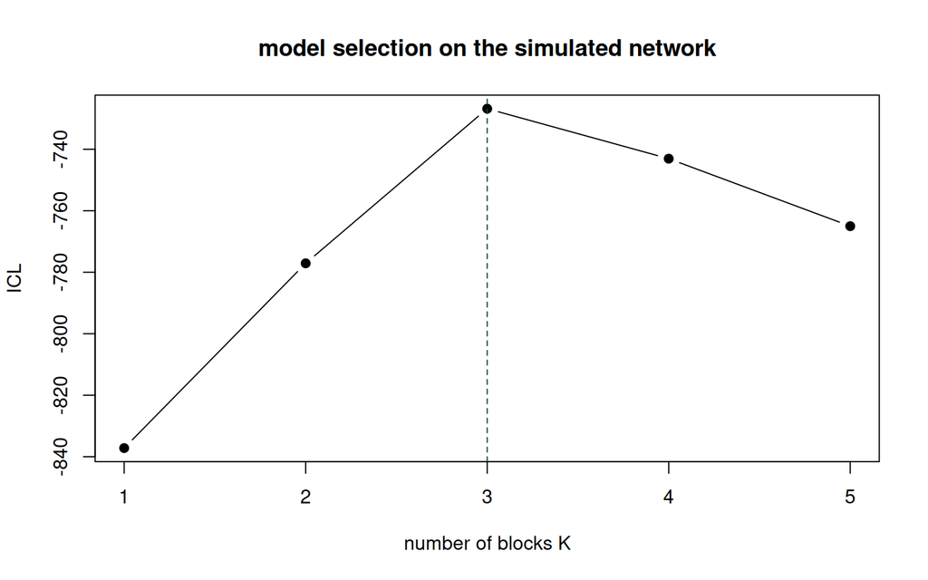

Integrated completed likelihood (ICL) for each candidate number of blocks. Higher is better. The peak is where adding blocks stops being worth the cost. The model-selection section after the break is about this curve. For now, note that it peaks at the K we planted.

```r
icl <- fit_sim$ICL
best_K <- which.max(icl)
plot(seq_along(icl), icl, type = "b", pch = 19,
     xlab = "number of blocks K", ylab = "ICL",
     main = "model selection on the simulated network")
abline(v = best_K, lty = 2, col = "#18453B")
```

The estimator’s preferred number of blocks is 3, exactly the 3 we planted. Now pull the block assignments out of the fitted object. `blockmodels` stores a soft-membership matrix `Z` (rows are actors, columns are blocks, each row sums to 1); we take each actor’s most probable block with `which.max`.

```r
Z_hat  <- fit_sim$memberships[[best_K]]$Z
z_hat  <- apply(Z_hat, 1, which.max)
table(truth = z_true, estimated = z_hat)
```

```
#>      estimated
#> truth  1  2  3
#>     1  0 20  0
#>     2 20  0  0
#>     3  0  0 20
```

```r
# Co-membership agreement: over all actor pairs, do truth and estimate
# agree on whether the two share a block? This is permutation-invariant,
# so label switching does not fool it. 1.0 means a perfect partition.
same_true <- outer(z_true, z_true, `==`)
same_hat  <- outer(z_hat,  z_hat,  `==`)
checkpoint(planted_K = length(unique(z_true)),
           chosen_K  = best_K,
           pair_agreement = mean(same_true[upper.tri(same_true)] ==
                                 same_hat[upper.tri(same_hat)]))
```

```
#> ------------------------------------------------------------------
#> CHECKPOINT: planted_K = 3   |   chosen_K = 3   |   pair_agreement = 1
#> ------------------------------------------------------------------
```

And the recovered $\theta$ matches the recipe we started from within sampling noise: the estimated within-block probability is near 0.45 and the between-block near 0.05:

```r
round(fit_sim$model_parameters[[best_K]]$pi, 3)
```

```
#>       [,1]  [,2]  [,3]
#> [1,] 0.445 0.056 0.044
#> [2,] 0.056 0.471 0.054
#> [3,] 0.044 0.054 0.434
```

**ImportantThis is the whole method**

Hand the blockmodel a network, and it hands you back (a) how many discrete types of actor there are, (b) which type each actor is, with a probability, not just a label, and (c) the full table of how the types connect. It did that here by inverting the exact generative recipe we wrote in Section 12. Everything from here is doing this on data where we do *not* know the truth, and learning to distrust it well.

Break. You now have the full blockmodel machinery on data you built: recipe, likelihood, recovery. After the break: how many blocks, a structure community detection cannot name, and a real network where nobody planted the blocks.

# 15 How many blocks? Model selection

On the simulated network we knew the answer was three. On real data there is no true $K$, and you cannot just maximize the likelihood: adding blocks *always* raises the likelihood (in the limit, one block per actor fits any network perfectly and explains nothing). You need a criterion that trades fit against complexity.

`blockmodels` selects $K$ with the **integrated completed likelihood (ICL)**; schematically, a criterion of this form trades fit against complexity:

$$\text{ICL} \;\approx\; \underbrace{\log L(\hat z, \hat\theta \mid Y)}_{\text{fit}}
\;-\; \underbrace{\tfrac{K(K+1)}{4}\log\tfrac{n(n-1)}{2}}_{\substack{\text{the } K(K+1)/2 \text{ block probs}\\ \text{(symmetric; } K^2\!/2 \text{ if directed)}}}
\;-\; \underbrace{\tfrac{K-1}{2}\log n}_{\substack{\text{the } K-1 \text{ mixing-}\\ \text{proportion parameters}}} .$$

The first term wants more blocks; the two penalties want fewer. ICL peaks where the next block would buy less fit than it costs in complexity, and it is **close in spirit to BIC**. Two honest caveats. First, the block count is $K(K+1)/2$ here because this is a *symmetric* fit ($\theta$ has a shared upper and lower triangle); the directed SBM we run on trade below carries the full $K^2$. Second, the numbers you actually see in `fit$ICL` are the package’s completed-data variational version of this, with an entropy term for the soft assignments. That entropy is what makes it an *integrated completed* likelihood rather than a plain BIC, not this closed form. Treat the equation as the shape of the tradeoff, not the package’s arithmetic. You already saw it work: on the simulated data it peaked at the planted $K$.

**WarningICL is a guide, not an oracle**

Pick $K$ by ICL, then **look at the solution**. A peak at $K=7$ that splits your network into five singletons and two real groups is telling you the criterion and your substantive question disagree. Common, defensible moves: take the ICL peak; take the “elbow” if the curve is flat near the top and a smaller $K$ is nearly as good; or fix $K$ from theory if you have a reason to expect a specific number of roles. The one thing you may not do is pick $K$ to make a story work and not say so.

# 16 Blocks are not communities

Here is the payoff of building a *model* rather than optimizing a score. We will generate a network with genuine structure that is **not** assortative, hand it to both community detection and the blockmodel, and watch only one of them succeed.

The structure is **core-periphery**: a small “core” whose members tie densely to each other and reach out to everyone, and a large “periphery” whose members tie to the core but almost never to each other. Think of a handful of hub organizations everyone coordinates through, surrounded by many groups that only touch the hubs.

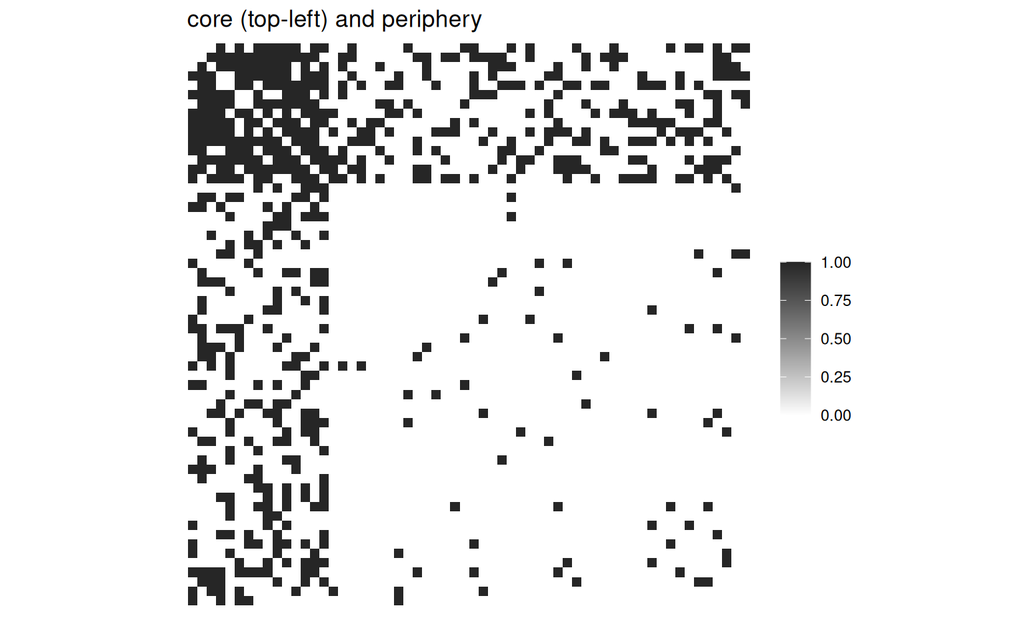

A core-periphery network. The top-left 15-by-15 block (the core) is dense and reaches out; the large periphery block is nearly empty on its own diagonal. This is real, strong structure, but it is not community structure.

```r
set.seed(6886)
z_cp <- c(rep(1, 15), rep(2, 45))            # 15 core, 45 periphery
theta_cp <- matrix(c(0.80, 0.30,             # Core-core, core-periphery
                     0.30, 0.03), 2, 2)      # Periphery-core, periph-periph
A_cp <- sim_sbm_binary(z_cp, theta_cp)
plot_adj(A_cp, blocks = z_cp, title = "core (top-left) and periphery")
```

First, community detection. Louvain is *defined* to hunt for within-group density, and the periphery has none, so it has nowhere to put those actors:

```r
g_cp <- graph_from_adjacency_matrix(A_cp, mode = "undirected", diag = FALSE)
set.seed(6886)
lc_cp <- cluster_louvain(g_cp)
c(communities_found = length(unique(membership(lc_cp))),
  modularity        = round(modularity(lc_cp), 3))
```

```
#> communities_found        modularity
#>             5.000             0.182
```

Louvain reports 5 communities and a modularity of only 0.18, it has *shattered* the periphery into several spurious groups because it cannot represent “these actors belong together by virtue of not connecting to each other.” The true structure has two roles; Louvain sees 5 communities and none of them is the core-periphery split.

Now the blockmodel, same one-line call as before:

```r
set.seed(6886)
fit_cp <- BM_bernoulli("SBM_sym", A_cp, verbosity = 0,
                       plotting = "",
                       explore_min = 2)  # explore_min/explore_max bound the K search;
                                         # here: do not stop before trying K = 2
fit_cp$estimate()
```

```r
K_cp  <- which.max(fit_cp$ICL)
z_cp_hat <- apply(fit_cp$memberships[[K_cp]]$Z, 1, which.max)
table(truth = z_cp, estimated = z_cp_hat)
```

```
#>      estimated
#> truth  1  2
#>     1  0 15
#>     2 45  0
```

The blockmodel recovers the two roles cleanly, and, crucially, the recovered $\theta$ *names the structure* as core-periphery: a dense diagonal for the core, a near-empty diagonal for the periphery, and a moderate cross term.

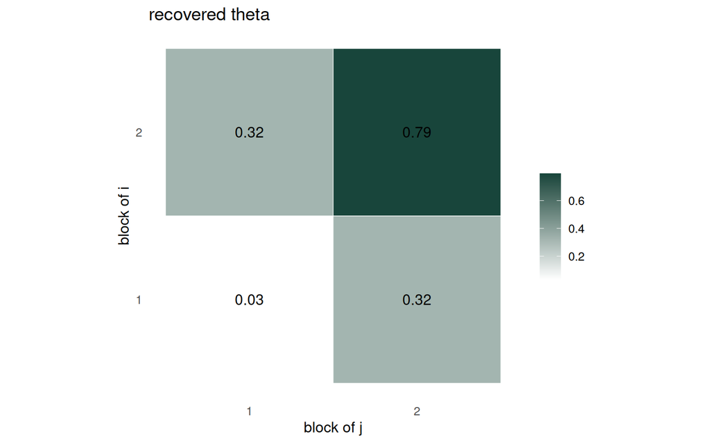

Recovered block-connectivity matrix for the core-periphery network. One block ties to itself at about 0.8, the other at about 0.03, with a cross-term of about 0.3. Read off the numbers: that is a core and a periphery, stated as probabilities.

```r
plot_theta(fit_cp$model_parameters[[K_cp]]$pi, "recovered theta")
```

**ImportantWhat the model bought you**

Community detection asked, “Who clusters together?”, and got the wrong answer because the question was wrong for this network. The blockmodel asked, “What grouping makes the observed network most probable?”, and got core-periphery, a structure that has no name in the community-detection vocabulary. **A blockmodel finds roles, not just cliques.** That is the first of the four things a model buys that a score does not; the other three, likelihood, uncertainty, and generative prediction, we use in the next two sections.

# 17 Blocks in a real network: trade

Let’s put it on the same data the first half of today used, directed international trade among 30 countries, so the discrete answer sits right next to this morning’s additive one on the *same* network. We load the blocks-era copy of the trade edgelist from this day’s own `data/` folder (same network, fresh copy, it also resets the working columns we added this morning).

```r
load("data/day10_blocks.rda")   # Brings in `trade` (edgelist) and more
head(trade[, 1:5])
```

|  | Var1 | Var2 | trade | conflicts | distance |
| --- | --- | --- | --- | --- | --- |
| 2 | AUL | ARG | 0.8891828 | 0 | 11.72 |
| 3 | BEL | ARG | 0.2700271 | 0 | 11.31 |
| 4 | BNG | ARG | 0.0000000 | 0 | 16.76 |
| 5 | BRA | ARG | 0.8700434 | 0 | 2.35 |
| 6 | CAN | ARG | 0.1906204 | 0 | 9.07 |
| 7 | CHN | ARG | 1.2528095 | 0 | 19.26 |

Trade is *weighted* (logged export volume), not binary, so the coin-flip Bernoulli SBM is the wrong family. The generative story is identical: actors come in blocks, and a pair’s value depends only on the two blocks. Now $\theta_{ab}$ is a **mean** rather than a probability, and the model is `BM_gaussian`. We also follow the original analysis and partial distance out first, because two countries being far apart is a geographic fact we do not want the blocks to rediscover; we want blocks in what is *left* after distance.

```r
# Residualize trade on distance, then reshape to an n x n matrix
trade$trade_resid <- resid(lm(trade ~ distance, data = trade))
yMat <- acast(trade, Var1 ~ Var2, value.var = "trade_resid")
diag(yMat) <- 0                        # blockmodels wants no NAs
dim(yMat)
```

```
#> [1] 30 30
```

(Yes, that is the hand-rolled `acast()` Section 5 warned you about. It is safe here because we reshape only the *outcome*, there are no covariate objects to misalign. The morning’s warning was about building multiple aligned objects with mixed tools.)

Fit the Gaussian SBM and let ICL choose the number of blocks:

```r
set.seed(6886)
fit_tr <- BM_gaussian("SBM", yMat, verbosity = 0, plotting = "")
fit_tr$estimate()
```

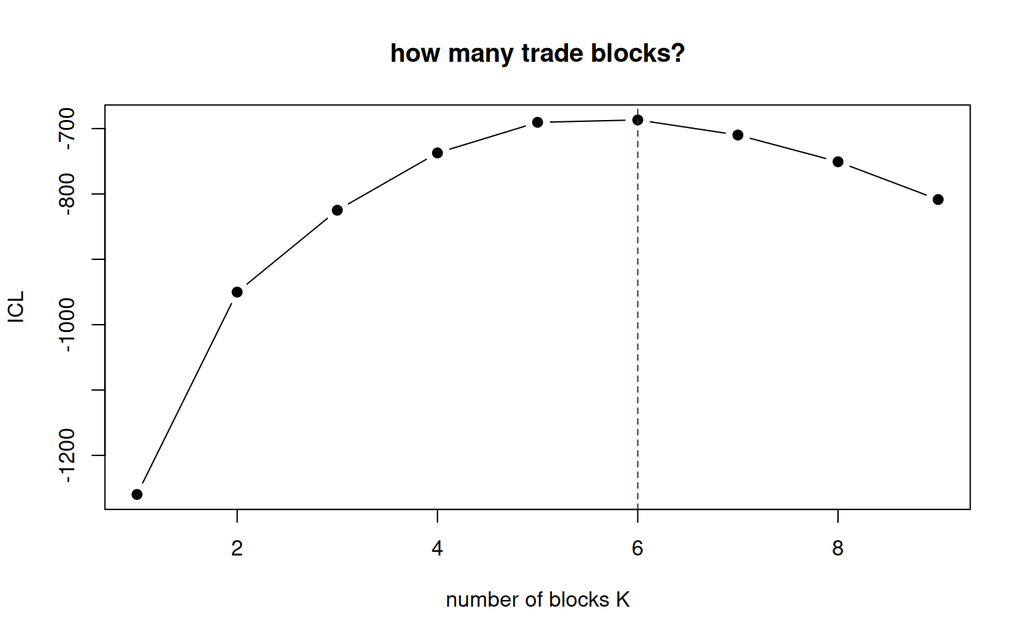

ICL across candidate block counts for the trade network. The peak picks how many country-types the data supports.

```r
icl_tr <- fit_tr$ICL
K_tr   <- which.max(icl_tr)
plot(seq_along(icl_tr), icl_tr, type = "b", pch = 19,
     xlab = "number of blocks K", ylab = "ICL",
     main = "how many trade blocks?")
abline(v = K_tr, lty = 2, col = "#18453B")
```

ICL prefers 6 blocks. Pull out the assignments and see how big each block is:

```r
z_tr <- apply(fit_tr$memberships[[K_tr]]$Z, 1, which.max)
names(z_tr) <- rownames(yMat)
sort(table(z_tr))
```

```
#> z_tr
#>  6  2  4  5  1  3
#>  1  2  4  6  7 10
```

The 6 blocks range from a singleton up to a block of 10 countries. Now the two things you always look at: *which* countries share a block, and *how* the blocks connect.

```r
split(names(z_tr), z_tr)
```

```
#> $`1`
#> [1] "ARG" "INS" "PHI" "SAF" "SAU" "SWD" "THI"
#>
#> $`2`
#> [1] "CAN" "ROK"
#>
#> $`3`
#>  [1] "BNG" "BRA" "COL" "EGY" "IND" "IRN" "MEX" "PAK" "POL" "TUR"
#>
#> $`4`
#> [1] "AUL" "CHN" "JPN" "TAW"
#>
#> $`5`
#> [1] "BEL" "FRN" "ITA" "NTH" "SPN" "UKG"
#>
#> $`6`
#> [1] "USA"
```

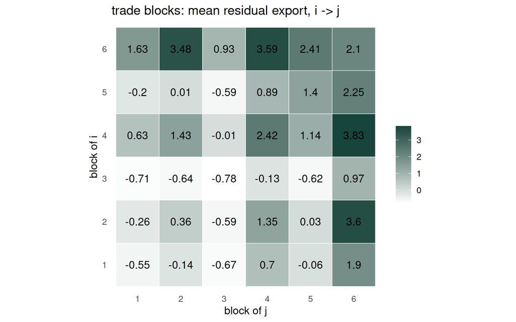

Block-connectivity matrix for trade (mean residual trade from block i to block j). Darker means block i sends more to block j than distance alone predicts. This is a directed network, so the matrix is not symmetric; read rows as senders and columns as receivers.

```r
plot_theta(round(fit_tr$model_parameters[[K_tr]]$mu, 2),
           "trade blocks: mean residual export, i -> j")
```

Now read the result like a finding, not a printout, starting by firing the Section 15 warning at our own output. ICL bought 6 blocks, and it spent one of them on a single country (USA gets a block to itself) and another on a duo (CAN, ROK). That is the criterion saying the United States’ trade profile is so unlike everyone else’s that no block will hold it. That is substantively defensible here, but exactly the singleton pattern the warning callout told you to stop and inspect rather than narrate past.

Second, the asymmetry is readable. Score each block by its row mean minus its column mean in $\theta$, how much more it *sends* than it *receives*, net of distance:

```r
mu_tr   <- fit_tr$model_parameters[[K_tr]]$mu
net_out <- round(rowMeans(mu_tr) - colMeans(mu_tr), 2)
net_out
```

```
#> [1]  0.11  0.00 -0.03  0.10 -0.09 -0.08
```

The most net-exporting type is block 1 (ARG, INS, PHI, SAF, SAU, SWD, THI), a mix of mid-sized economies heavy on commodity exporters, with the Asia-Pacific export economies (block 4: AUL, CHN, JPN, TAW) just behind, while the European core and the United States come out as net *receivers* of residual trade. Remember what “residual” means before you over-read this: distance is already partialled out, so this is not “who trades most,” it is “who over-sends relative to geography.”

And the picture that makes the whole thing concrete, the trade matrix reordered so block-mates are adjacent. If the blocks are real, you should see the matrix organize into blocks of similar shade:

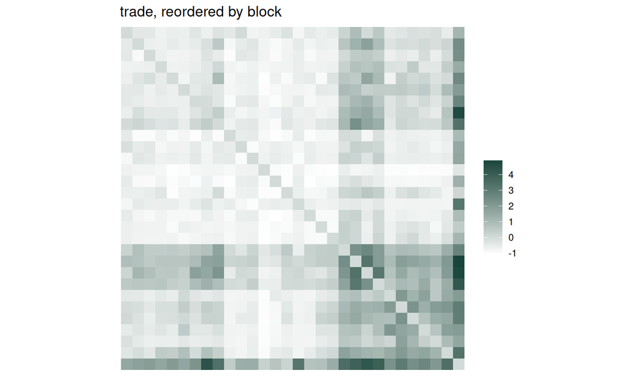

Residual trade matrix, with countries reordered by estimated block. The model claims these blocks are the structure; the reordered matrix lets you judge whether it found real bands or imposed arbitrary lines.

```r
plot_adj(yMat, blocks = z_tr, low = "#FFFFFF", high = "#18453B",
         title = "trade, reordered by block")
```

**NoteReading a directed block matrix substantively**

Because trade is directed, $\theta$ is not symmetric, and that asymmetry is the interesting part. A block with a large value in its *row* but a small value in its *column* is a net exporter type: it sends more than it receives, above and beyond what distance explains. That is exactly the row-minus-column score we computed above. This is the same sender/receiver asymmetry the SRM captured this morning with $a_i$ and $b_j$, but where the SRM gave every country its own continuous number, the blockmodel says there are only 6 *kinds* of country and forces each one into a kind. Whether that is a feature or a bug is what the goodness-of-fit check decides.

**NoteThe full toolbox: what else a fitted `blockmodels` object can do**

We pulled `$ICL`, `$memberships` and `$model_parameters` out of `fit_tr` by hand because each extraction taught something. The object carries more.

**The model’s own predictions.** `$prediction(K)` returns the $n \times n$ expected-value matrix, what the world would look like if the blockmodel were exactly right:

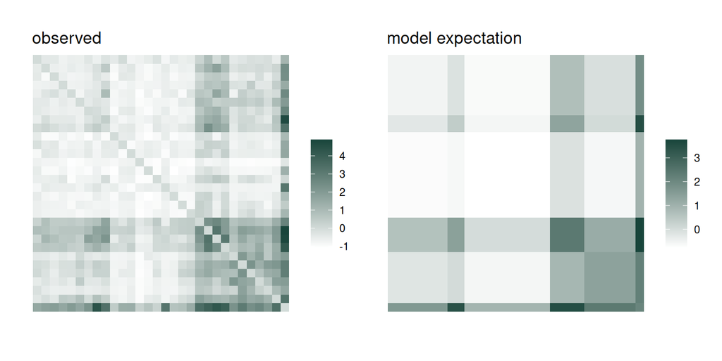

Observed residual trade (left) and the blockmodel’s expected values (right), using the same block ordering. The model’s entire view of the world is K by K distinct shades. That is the compression bet made visible.

```r
P_tr <- fit_tr$prediction(K_tr)     # n x n expected values at K_tr blocks
dimnames(P_tr) <- dimnames(yMat)    # prediction() drops the actor names
plot_adj(yMat, blocks = z_tr, low = "#FFFFFF", high = "#18453B",
         title = "observed") +
  plot_adj(P_tr, blocks = z_tr, low = "#FFFFFF", high = "#18453B",
           title = "model expectation")
```

The two matrices correlate at 0.91, with 6 blocks on 30 countries, the compression is doing real work.

**The built-in plots.** We drew our own `plot_adj()` and `plot_theta()` so every pixel was explained, but the package ships its own diagnostics. They are less pretty but require zero setup:

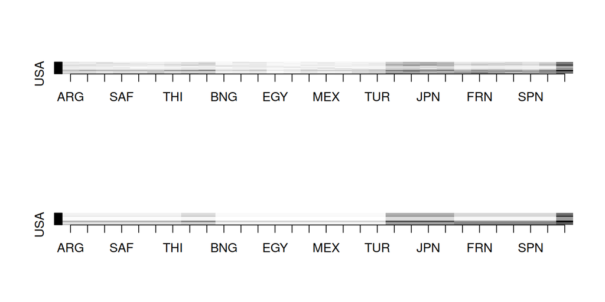

```r
fit_tr$plot_obs_pred(K_tr)          # Observed vs predicted, side by side
```

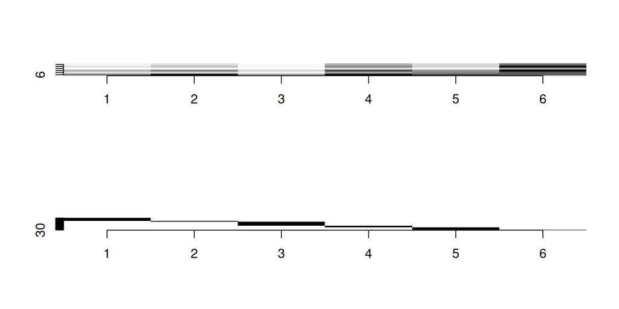

```r
fit_tr$plot_parameters(K_tr)        # The K x K parameter estimates
fit_tr$memberships[[K_tr]]$plot()   # Soft membership per actor
```

**Covariates inside the SBM.** We residualized distance out *before* fitting, which was a two-step answer. The `BM_*_covariates` classes ask the one-step question, estimate the blocks and the covariate effect jointly, on the raw matrix:

```r
distMat <- acast(trade, Var1 ~ Var2, value.var = "distance"); diag(distMat) <- 0
yRawCov <- acast(trade, Var1 ~ Var2, value.var = "trade");    diag(yRawCov) <- 0
set.seed(6886)
fit_cov <- BM_gaussian_covariates("SBM", yRawCov,
                                  covariates = list(distance = distMat),
                                  verbosity = 0, plotting = "")
fit_cov$estimate()
```

```r
K_cov <- which.max(fit_cov$ICL)
c(K = K_cov, beta_distance = round(fit_cov$model_parameters[[K_cov]]$beta, 3))
```

```
#>             K beta_distance
#>         6.000        -0.038
```

The distance coefficient comes out negative (-0.038), as trade gravity says it must, and ICL now prefers 6 blocks, not necessarily the 6 from the residualized fit, because “blocks after removing distance by regression” and “blocks jointly estimated with a distance effect” are different questions. The binary version is `BM_bernoulli_covariates`, same pattern.

# 18 Does it fit?

We have the four things community detection lacked; now we use the generative one. Because the blockmodel is a recipe we can run *forward*, we can simulate networks from the fitted model and ask whether they look like the real one on statistics we care about. This is the same predictive-simulation logic the SRM half used this morning, with one honest difference in the label: the SRM simulated across posterior draws (a true posterior predictive check), while here we simulate from the single fitted point estimate, which makes this a **parametric bootstrap**. VEM gives us no posterior to draw from (the callout in Section 13). We will reuse the exact GOF statistics tomorrow’s latent-variable models use, so the numbers are comparable across the whole course.

```r
# The course-standard gof statistics: actor-level heterogeneity, and
# two flavours of third-order (triadic) dependence.
calc_gof <- function(mat) {
  actor_sd <- sd(rowMeans(mat, na.rm = TRUE), na.rm = TRUE)
  E <- mat - mean(mat, na.rm = TRUE)
  D <- 1 * (!is.na(E)); E[is.na(E)] <- 0
  s3 <- sd(c(mat), na.rm = TRUE)^3
  cycle <- sum(diag(E %*% E %*% E)) /
           (sum(diag(D %*% D %*% D)) * s3)
  trans <- sum(diag(E %*% t(E) %*% E)) /
           (sum(diag(D %*% t(D) %*% D)) * s3)
  out <- c(actor_sd, cycle, trans)
  out[is.na(out)] <- 0
  setNames(out, c("actor_sd", "cycle", "trans"))
}
```

One scorekeeping disclosure before we keep score: these statistics are the ones tomorrow’s latent-variable models report, chosen so numbers stay comparable across the whole course, which also means they are the moments the `amen`/`lame` family is parameterized to reproduce. The blockmodel literature keeps score differently, held-out tie prediction and description length (Peixoto 2019), and on those margins SBMs are strong. A model can lose on our moments and win on theirs; we are saying which game we are scoring, not that it is the only game.

Simulate from the fitted Gaussian SBM, draw each cell from a normal centered on its block-pair mean $\theta_{z_i z_j}$ with the fitted residual standard deviation, and compare the observed statistics to the distribution across simulations:

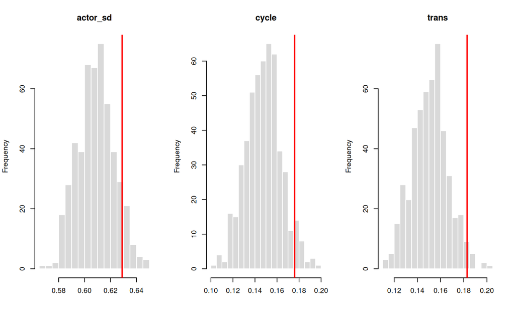

For each GOF statistic, the histogram contains 500 networks simulated from the fitted blockmodel, and the red line is the observed trade network. We want the line inside the mass. Actor heterogeneity is the one to watch.

```r
mu_tr  <- fit_tr$model_parameters[[K_tr]]$mu
sig_tr <- sqrt(fit_tr$model_parameters[[K_tr]]$sigma2)
n_tr   <- nrow(yMat)

sim_gauss_sbm <- function() {
  M <- matrix(rnorm(n_tr * n_tr,
                    mean = as.vector(mu_tr[z_tr, z_tr]),
                    sd = sig_tr), n_tr, n_tr)
  diag(M) <- NA
  M
}

set.seed(6886)
gof_obs <- calc_gof(yMat)
gof_sim <- t(replicate(500, calc_gof(sim_gauss_sbm())))

par(mfrow = c(1, 3))
for (s in colnames(gof_sim)) {
  hist(gof_sim[, s], breaks = 25, col = "grey85", border = "white",
       main = s, xlab = "")
  abline(v = gof_obs[s], col = "red", lwd = 2)
}
```

```r
par(mfrow = c(1, 1))
```

Put a number on it, how many simulated standard deviations away is the observed value?

```r
z_scores <- round(abs(gof_obs - colMeans(gof_sim)) / apply(gof_sim, 2, sd), 2)
z_scores
```

```
#> actor_sd    cycle    trans
#>     1.44     1.74     2.06
```

The blockmodel does a **respectable** job on trade: actor heterogeneity is 1.44 sds off, and the triadic statistics are 1.74 and 2.06. It is capturing real structure, because with 6 blocks and a full mean matrix, blocks can absorb a lot of the country-to-country variation. Hold onto that actor-heterogeneity number, 1.44: it is a control. In the next section we hand the **identical** test, same `calc_gof`, same 500-simulation logic, to a different network, and the same kind of model misses by nearly an order of magnitude more. The discrete story is not always this kind.

# 19 When a plain blockmodel misses: diagnose the miss

The natural question is when the discrete bet wins and when a fitted blockmodel misses. There are at least two different diagnoses: the roles may not be discrete, or the roles may be fine while the model lacks a separate activity term. This example is useful because the first score looks like a loss for boxes, then a simple control tells us which diagnosis the evidence actually supports.

The data is from Gade, Gabbay, Hafez & Kelly (2019): cooperation among Syrian rebel groups, a symmetric binary network of actors who either coordinate or do not. We hold three models to the *same* GOF statistics: a **mixed-membership blockmodel** (today’s family, except each actor gets a probability distribution over blocks instead of a single hard label, with covariates), this morning’s **SRM**, and a **latent-factor model** (Day 3, tomorrow). Only the genuinely expensive fit, the latent-factor model, with its 50,000-draw burn-in, ships precomputed in `data/`; the collapsible below records exactly how it was made. The mixed-membership blockmodel refits in about twenty seconds, so we fit it ourselves, on screen, like every other model today.

```r
suppressMessages(library(NetMix))
# load() returns the saved object's NAME as a string; get() fetches the
# object it names. (The bare load() below just drops the object into the
# environment under its own name, same idea, two idioms.)
gade <- get(load("data/gade_app.rda"))          # Mirror-doubled dyadic data.frame
gade$coop <- as.numeric(gade$coopActions > 0)
gnet <- netify(gade, actor1 = "actor1", actor2 = "actor2",
               symmetric = TRUE, weight = "coop")
gof_obs_g <- calc_gof(as.matrix(gnet))
round(gof_obs_g, 3)
```

```
#> actor_sd    cycle    trans
#>    0.184    0.007    0.007
```

```r
load("data/vecs_2.rda")     # A rank-2 latent factor model (lame)
```

That gives us 30 rebel groups, and the observed values of the three GOF statistics we will hold every model to.

## 19.1 The mixed-membership fit, live

NetMix’s `mmsbm()` is today’s blockmodel plus one idea: instead of a single hard label $z_i$, every actor gets a probability *distribution* over the $K$ blocks, so a group can be 60% block 1 and 40% block 4. Unlike `blockmodels`, it also takes covariates. That is why the call has two formulas: the first is dyadic (DV plus dyad-level covariates), the second monadic (actor-level covariates, which shape the memberships). `data.dyad` and `data.monad` supply the matching data frames, and `senderID`/`receiverID`/`nodeID` name the columns that link them.

```r
nodal_data <- unique(gade[, c("actor1", "averageId_actor1", "size_actor1")])
# The source data contain both i-j and j-i rows. Keep one unordered row and
# tell NetMix this is an undirected network. Its default is directed = TRUE.
gade_u <- gade[as.character(gade$actor1) < as.character(gade$actor2), ]
blocks_5 <- cache_fit("blocks_5_undirected", mmsbm(
  coop ~ ideol_diff + powerdiff,
  ~ averageId_actor1 + size_actor1,
  senderID = "actor1", receiverID = "actor2", nodeID = "actor1",
  data.dyad = gade_u, data.monad = nodal_data,
  n.blocks = 5,
  directed = FALSE,
  mmsbm.control = list(svi = TRUE, vi_iter = 100000, seed = 334)
))
```

`mmsbm.control` is the knob box: `svi = TRUE` uses stochastic variational inference (subsampled updates, fast, and the reason the trajectory below is noisy), `vi_iter` caps the iterations, and `seed` pins the run. Two more worth knowing: `conv_tol` (the stopping tolerance, default 0.001) and `hessian` (standard errors for the coefficients, on by default); the remaining knobs, `nstart` (random initializations, default 5) and `assortative` (constrain the blockmodel toward community-like structure), are in `?mmsbm`. This is a variational optimizer, not MCMC, so the convergence check differs from this morning’s: no trace plots, you check the flag and look at the objective, the **evidence lower bound** (the ELBO from the estimation collapsible in Section 13):

```r
checkpoint(converged = blocks_5$converged, iterations = blocks_5$niter,
           final_elbo = round(blocks_5$LowerBound, 1))
```

```
#> ------------------------------------------------------------------
#> CHECKPOINT: converged = TRUE   |   iterations = 10676   |   final_elbo = -43.8
#> ------------------------------------------------------------------
```

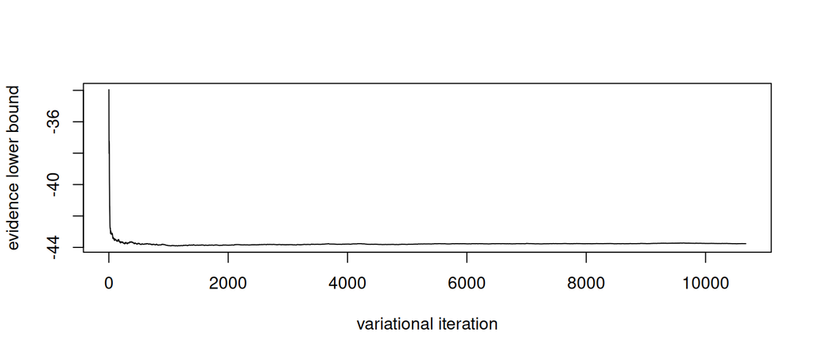

The variational objective per iteration. Under SVI, the early iterations are not comparable because the subsampled bound settles quickly. Look for the long flat tail: the optimizer stopped because it stopped improving, not because it hit the vi_iter cap.

```r
plot(blocks_5$LowerBound_full, type = "l",
     xlab = "variational iteration", ylab = "evidence lower bound")
```

```r
summary(blocks_5)
```

```
#> $`Number of Dyads`
#> [1] 435
#>
#> $`Number of Blocks`
#> [1] 5
#>
#> $`Percent of Observations in Each Block`
#> [1] 0.2122385 0.1509306 0.1583090 0.2398382 0.2386839
#>
#> $`Blockmodel Matrix`
#>            Group 1     Group 2     Group 3    Group 4    Group 5
#> Group 1 0.28402004 0.008934040 0.011704422 0.22756260 0.22330313
#> Group 2 0.00893404 0.180102176 0.005933103 0.01258626 0.01238149
#> Group 3 0.01170442 0.005933103 0.163824220 0.01795783 0.01762578
#> Group 4 0.22756260 0.012586263 0.017957834 0.46306924 0.34537904
#> Group 5 0.22330313 0.012381485 0.017625780 0.34537904 0.45384990
#>
#> $`Monadic Coefficients`
#>                                  Coefficient Std. Error
#> State 1:Group 1:(Intercept)       3.66158027   4.838323
#> State 1:Group 1:averageId_actor1 -0.07296014   5.110259
#> State 1:Group 1:size_actor1      -0.01392106   4.920747
#> State 1:Group 2:(Intercept)       3.35697606   4.839311
#> State 1:Group 2:averageId_actor1 -0.07431801   5.118975
#> State 1:Group 2:size_actor1      -0.01666355   4.917120
#> State 1:Group 3:(Intercept)       3.40589857   4.842830
#> State 1:Group 3:averageId_actor1 -0.07512681   5.112984
#> State 1:Group 3:size_actor1      -0.01665224   4.923889
#> State 1:Group 4:(Intercept)       3.76717836   4.835563
#> State 1:Group 4:averageId_actor1 -0.07239143   5.134149
#> State 1:Group 4:size_actor1      -0.01281981   4.908467
#> State 1:Group 5:(Intercept)       3.76313355   4.844227
#> State 1:Group 5:averageId_actor1 -0.07242725   5.125101
#> State 1:Group 5:size_actor1      -0.01287098   4.915454
#>
#> $`Dyadic Coefficients`
#>             Coefficient Std. Error
#> ideol_diff -0.105435383   1.971707
#> powerdiff  -0.000819306   1.964228
```

Read `summary()` in three pieces. The block-share line says how the mass spreads over the five blocks. The `Blockmodel Matrix` is $\theta$, already in probability units. The two coefficient tables, dyadic and monadic, use Hessian standard errors and make up the covariate half: the point estimates are negative, but with standard errors that size on 30 actors, this fit does not estimate them precisely enough for a directional claim. Inside the object, the block matrix lives on the log-odds scale as `$BlockModel`; `plogis()` is the bridge to what `summary()` printed:

```r
round(plogis(blocks_5$BlockModel), 2)   # Summary's Blockmodel Matrix, by hand
```

```
#>         Group 1 Group 2 Group 3 Group 4 Group 5
#> Group 1    0.28    0.01    0.01    0.23    0.22
#> Group 2    0.01    0.18    0.01    0.01    0.01
#> Group 3    0.01    0.01    0.16    0.02    0.02
#> Group 4    0.23    0.01    0.02    0.46    0.35
#> Group 5    0.22    0.01    0.02    0.35    0.45
```

Every diagonal cell is the largest in its row, so this particular $K=5$ solution is broadly assortative. It is not five isolated communities, though: blocks 4 and 5 inter-tie at about 0.35, and block 1 connects substantially to both. The matrix tells us the fitted block-level story; the GOF test below asks whether that story is enough. One honest disclosure before we run it: $K = 5$ was chosen by hand. NetMix has no ICL, so treat the fitted role structure and every downstream comparison as conditional on that choice.

**NoteProvenance: how the precomputed latent-factor fit was made**

Nothing about `vecs_2` is mysterious, it is slow (a 50,000-draw burn-in, a couple of minutes), so it ships precomputed. The shipped file was produced by exactly this call, run with the course’s `lame` build against the same `gade` data frame loaded above:

```r
# vecs_2: rank-2 latent factor model (lame), same covariates
gl <- to_lame(netify(gade, actor1 = "actor1", actor2 = "actor2",
                     symmetric = TRUE, weight = "coop",
                     nodal_vars = c("averageId_actor1", "size_actor1"),
                     dyad_vars = c("ideol_diff", "powerdiff")))
vecs_2 <- ame(Y = gl$Y, Xdyad = gl$Xdyad, Xrow = gl$Xrow,
              family = "binary", R = 2, symmetric = TRUE, seed = 6886,
              nscan = 10000, burn = 50000, odens = 5,
              plot = FALSE, verbose = FALSE)
```

Two facts you should demand of any precomputed fit before trusting a comparison built on it. First, the seed and iteration counts are in the call, and the sampler is deterministic given the seed, so a refit tonight should reproduce the shipped object *exactly*, and if it does not, your `lame` build differs from the course’s, which is itself worth knowing before you trust any cached fit. Second, the selection choices are disclosed: $K = 5$ was chosen by hand, so your own analysis should repeat the fit across defensible values of $K$ and across random starts. The legacy `data/blocks_5.rda` object was fitted with NetMix’s directed default to mirror-doubled rows and is deliberately not used here.

First, does the blockmodel reproduce the network’s **actor heterogeneity**, the fact that some groups cooperate far more than others? Simulate from the fitted mixed-membership blockmodel (from its fitted point estimate again, NetMix is variational too, so this is the same parametric bootstrap as Section 18) and compare:

```r
# blocks_5$dyadic.data is mmsbm's internal design frame (one row per
# dyad, in the order simulate() uses); its bookkeeping columns are
# literally named "(sid)" and "(rid)", parentheses included, which
# is why the quoted column names below are not a typo
dyad_order <- blocks_5$dyadic.data[, c("(sid)", "(rid)")]
sims_b <- simulate(blocks_5, nsim = 200, seed = 6886)
gof_b <- t(sapply(sims_b, function(v) {
  sd_df <- data.frame(sid = dyad_order[, 1], rid = dyad_order[, 2],
                      sim = v)
  sn <- netify(sd_df, actor1 = "sid", actor2 = "rid",
               symmetric = TRUE, weight = "sim")
  calc_gof(as.matrix(sn))
}))
z_block_actor <- abs(gof_obs_g["actor_sd"] - mean(gof_b[, "actor_sd"])) /
                 sd(gof_b[, "actor_sd"])
round(z_block_actor, 2)
```

```
#> actor_sd
#>    13.74
```

The blockmodel misses actor heterogeneity by 13.7 standard deviations. It is not close. Two checks before we diagnose it, first, what the model does *not* miss (the identical test on the two triadic statistics), and second, its soft memberships, shown rather than asserted:

```r
# Triadic z-scores for the same fitted blockmodel: it passes these
round(abs(gof_obs_g[c("cycle", "trans")] -
          colMeans(gof_b[, c("cycle", "trans")])) /
      apply(gof_b[, c("cycle", "trans")], 2, sd), 2)
```

```
#> cycle trans
#>   0.5   0.5
```

```r
# Each actor's single largest block probability, against uniform 1/5 = 0.2
summary(apply(blocks_5$MixedMembership, 2, max))
```

```
#>    Min. 1st Qu.  Median    Mean 3rd Qu.    Max.
#>  0.2326  0.2353  0.2379  0.2398  0.2408  0.2662
```

So the failure is *specific*: triangles are fine, activity is not. The membership profiles are also nearly uniform: every actor’s largest role weight sits only a little above 0.2. In a mixed-membership model those weights are the fitted blend of roles, not uncertainty about one hidden “true” class, so the careful reading is that the model assigns almost everyone a similarly diffuse role mixture. Hold the diagnosis for after the scorecard; neither the diffuse mixture nor the activity miss, by itself, proves that discreteness is the problem.

Now the latent-factor model, which places each actor at a *point* rather than in a box. Its GOF is carried inside the fitted object:

```r
G <- vecs_2$GOF                      # Row 1 observed, rest simulated
obs_lfm <- G[1, ]; sim_lfm <- G[-1, , drop = FALSE]
z_lfm_actor <- abs(obs_lfm["sd.rowmean"] - mean(sim_lfm[, "sd.rowmean"])) /
               sd(sim_lfm[, "sd.rowmean"])
round(z_lfm_actor, 2)
```

```
#> sd.rowmean
#>       0.35
```

And third, a control that uses only this morning’s machinery: an SRM with no blocks or latent geometry and just the additive activity term $a_i$ (`R = 0`; covariate-free, because the point here is the activity knob and nothing else), fit to the identical network. This one is cheap enough to run live, so it is `cache_fit()`-wrapped like the morning models:

```r
srm_gade <- cache_fit("srm_gade", ame(
  Y = as.matrix(gnet), family = "binary", symmetric = TRUE, R = 0,
  seed = 6886, nscan = 10000, burn = 10000, odens = 10,
  plot = FALSE, verbose = FALSE
))
Gs <- srm_gade$GOF
z_srm_actor <- abs(Gs[1, "sd.rowmean"] - mean(Gs[-1, "sd.rowmean"])) /
  sd(Gs[-1, "sd.rowmean"])
round(z_srm_actor, 2)
```

```
#> [1] 1.93
```

(One detail to notice if you print this fit: its variance components have no `rho` row. `ame()`’s `dcor` argument defaults to `!symmetric`, so a symmetric fit drops the within-dyad correlation automatically. With one undirected value per dyad, there is nothing left to reciprocate.)

The whole payoff of the comparison is one jump: the same actor-heterogeneity statistic, checked with each model’s own simulation machinery. The two SBMs use fitted-parameter bootstraps, while the Bayesian SRM and factor model use posterior predictive draws, so compare the diagnostic pattern rather than treating the four z-scores as one common sampling test.

```r
data.frame(
  network    = c("trade (residual)", "rebel cooperation",
                 "rebel cooperation", "rebel cooperation"),
  model      = c("gaussian SBM", "mixed-membership SBM",
                 "SRM (this morning)", "latent factor (Day 3)"),
  actor_sd_z = round(as.numeric(c(z_scores["actor_sd"], z_block_actor,
                                  z_srm_actor, z_lfm_actor)), 2),
  verdict    = c("pass", "fail (no activity term)",
                 "pass (a_i alone)", "pass (a_i + latent u_i)"))
```

| network | model | actor_sd_z | verdict |
| --- | --- | --- | --- |
| trade (residual) | gaussian SBM | 1.44 | pass |
| rebel cooperation | mixed-membership SBM | 13.74 | fail (no activity term) |
| rebel cooperation | SRM (this morning) | 1.93 | pass (a_i alone) |
| rebel cooperation | latent factor (Day 3) | 0.35 | pass (a_i + latent u_i) |

Read the third row hardest, because it is the diagnosis. This morning’s SRM, which has no blocks and no latent geometry at all, takes the same statistic from 13.7 down to 1.9 sds, and the latent-factor model (which carries the same additive $a_i$ *plus* a latent position) finishes the job at 0.35. That tells you exactly what did the work: `actor_sd` is `sd(rowMeans)`, a pure **activity/degree** statistic, and the mixed-membership SBM is the only model on the card with **no term for it**, an actor’s expected activity is pinned by its block memberships, so within-block activity variation has nowhere to land. The honest reading of the scorecard is therefore not “points beat boxes” full stop, it is “the models with an activity knob reproduce the activity statistic, and the model without one cannot.” What tomorrow’s continuous geometry adds beyond this morning’s $a_i$ is the fine-grained *who-with-whom* structure; the verdict callout below names the discrete world’s own fix.

**ImportantThe honest verdict on blockmodels**

Blockmodels are the right tool when your actors genuinely come in a few sharp kinds, and when they do, no other model in this course states the structure as cleanly, or finds roles like core-periphery that community detection cannot even name.

Be equally careful attributing today’s miss. The `actor_sd` failure is a **missing degree-correction term**, not discreteness as such, the scorecard itself proved that, since the fully non-discrete part of the fix (the SRM’s $a_i$) closed most of the gap on its own. The discrete world has its own version of that knob: the **degree-corrected SBM** (Karrer & Newman 2011) keeps the boxes and adds one continuous activity parameter per actor, the block world’s $a_i$, and is built by construction to absorb exactly what you watched the plain mixed-membership SBM throw away. (It is also the cure for the vanilla SBM’s canonical failure mode: with no activity term, an SBM will press its *blocks* into service soaking up degree, splitting a community’s hubs into a spurious “high-degree block.” Implementations live mostly outside R, including Peixoto’s graph-tool in Python.) We did not run one today, so “it would close much of the gap” is an argument from its construction, not a number on the card.

That means the fair fight, boxes *with* a degree knob versus points, is still open at the end of today, and saying so is the honest state of the comparison, not a dodge. What Day 3 stages is the same question one cell over: which *continuous geometries* can express which structures? You will watch one continuous model (the latent distance model) fail on exactly the disassortative structure today’s blockmodels handle effortlessly, and another (the eigenmodel / latent-factor family) contain both, with planted-block machinery just like this afternoon’s reused as the test cases. Everything you learned today, the generative story, the likelihood, GOF by simulation, transfers directly; only the shape of the latent position changes, from a box to a point.

**NoteThe full toolbox: the rest of the NetMix surface**

The fitted `mmsbm` object answers the standard questions with the standard verbs:

```r
coef(blocks_5, param = "DyadCoef")                    # Point estimates
```

```
#>   ideol_diff    powerdiff
#> -0.105435383 -0.000819306
```

```r
round(sqrt(diag(vcov(blocks_5)$DyadCoef)), 2)         # Their standard errors
```

```
#> ideol_diff  powerdiff
#>       1.97       1.96
```

```r
head(round(predict(blocks_5, type = "response"), 3))  # Per-dyad tie probs
```

```
#> [1] 0.070 0.069 0.069 0.072 0.066 0.066
```

(`coef()` with no `param` returns both the monadic and dyadic sets; `vcov()` is a list with one block per parameter group, computed because `hessian = TRUE` is the default.)